# All Milestones

Gabriella Weis and Mason Polier

2024-12-08

### Disclaimer and Data Description

The categorical data in this dataset proved a bit difficult to work with, and in order to address some parts of the questions we wished to explore, it was necessary to make use of some methods we have not fully covered in class. I expect the numeric data in this dataset to be a lot easier to work with. For example, the two datasets are different in the way they record observations. The GDP dataset has observations based on Country. That is, every observation is a Country. However, the air quality dataset is different; instead, every observation is a city, and Country becomes another categorical variable. This meant that while every city listed in the dataset had an AQI Category (categorical), there was no averaged AQI Category for the entire Country. Because one of our questions required it, we went through the difficult process of averaging the numerical AQI values per Country and converting them into a general Country-wide AQI Category. Another issue with the data was the NA values for some Countries. We removed those values when creating bar graphs, but it makes the distribution not entirely accurate since we’re missing data. For example, the United States is missing all air quality data so we couldn’t use it for many of the bar graphs and tables below! We also adjusted some questions to make them easier to explore. With these things addressed and without further ado, let the data exploration begin.

# Milestone #4

### Setting Up

Load in tidyverse.

```r
library(tidyverse)
library(ggplot2)
```

Import the datasets and rename them.

```r
library(readxl)
gdp <- read_excel("C:/Users/glwei/OneDrive/Documents/Data Sci, Intro to R/gdp_percentages_2023.xlsx")
air <- read.csv("C:/Users/glwei/OneDrive/Documents/Data Sci, Intro to R/global air pollution dataset.csv")
```

### Q1: What is the distribution of cities across AQI categories (Good, Moderate, Unhealthy, etc.) in countries with a GDP over $1 trillion? How does this compare with countries with a GDP under $1 trillion? What does the distribution of cities in each category look like across countries with a GDP over $1 trillion?

Join data by country.

```r
combined_data <- left_join(gdp, air, by = "Country")
```

Reorder AQI factor levels.

```r
combined_data$`AQI.Category`<- factor(combined_data$`AQI.Category`,
                              levels = c("Good", "Moderate", "Unhealthy for Sensitive Groups", "Unhealthy", "Very Unhealthy", "Hazardous"))
```

Filter for Countries with a GDP over $1 trillion.

```r
gdp1t <- combined_data %>%
  filter(GDP > 1000)

gdp1t
```

```
## # A tibble: 11,856 × 17
##    Country     GDP Agriculture Industry Manufacturing Services City    AQI.Value
##    <chr>     <dbl>       <dbl>    <dbl>         <dbl>    <dbl> <chr>       <int>
##  1 Australia 1724.         2.4     27.4           5.4     64.2 Gerald…        29
##  2 Australia 1724.         2.4     27.4           5.4     64.2 Ballar…        22
##  3 Australia 1724.         2.4     27.4           5.4     64.2 Ballina        34
##  4 Australia 1724.         2.4     27.4           5.4     64.2 Bundab…        32
##  5 Australia 1724.         2.4     27.4           5.4     64.2 Port M…        29
##  6 Australia 1724.         2.4     27.4           5.4     64.2 Griffi…        24
##  7 Australia 1724.         2.4     27.4           5.4     64.2 Single…        31
##  8 Australia 1724.         2.4     27.4           5.4     64.2 Townsv…        23
##  9 Australia 1724.         2.4     27.4           5.4     64.2 Batema…        29
## 10 Australia 1724.         2.4     27.4           5.4     64.2 Burnie         26
## # ℹ 11,846 more rows
## # ℹ 9 more variables: AQI.Category <fct>, CO.AQI.Value <int>,
## #   CO.AQI.Category <chr>, Ozone.AQI.Value <int>, Ozone.AQI.Category <chr>,
## #   NO2.AQI.Value <int>, NO2.AQI.Category <chr>, PM2.5.AQI.Value <int>,
## #   PM2.5.AQI.Category <chr>
```

Make a table of counts.

```r
tableAqi <- table(gdp1t$AQI.Category)
print(tableAqi)
```

```
##
##                           Good                       Moderate
##                           5224                           3822
## Unhealthy for Sensitive Groups                      Unhealthy
##                            794                           1617
##                 Very Unhealthy                      Hazardous
##                            219                            168
```

```r
library(knitr)
kable(tableAqi, col.names = c('AQI Category', 'Count'),
      caption = "Distribution of Cities in Countries with a GDP Over $1 Trillion Across AQI Categories")
```

Distribution of Cities in Countries with a GDP Over $1 Trillion Across AQI Categories

| AQI Category | Count |
| --- | --- |
| Good | 5224 |
| Moderate | 3822 |
| Unhealthy for Sensitive Groups | 794 |
| Unhealthy | 1617 |
| Very Unhealthy | 219 |
| Hazardous | 168 |

Make a table of probabilities.

```r
ptableAqi <- prop.table(tableAqi)
print(ptableAqi)
```

```
##
##                           Good                       Moderate
##                     0.44106721                     0.32269504
## Unhealthy for Sensitive Groups                      Unhealthy
##                     0.06703816                     0.13652482
##                 Very Unhealthy                      Hazardous
##                     0.01849037                     0.01418440
```

```r
kable(ptableAqi, col.names = c('AQI Category', 'Relative Frequency'),
      caption = "Probability Distribution of Cities in Countries with a GDP Over $1 Trillion Across AQI Categories")
```

Probability Distribution of Cities in Countries with a GDP Over $1 Trillion Across AQI Categories

| AQI Category | Relative Frequency |
| --- | --- |
| Good | 0.4410672 |
| Moderate | 0.3226950 |
| Unhealthy for Sensitive Groups | 0.0670382 |
| Unhealthy | 0.1365248 |
| Very Unhealthy | 0.0184904 |
| Hazardous | 0.0141844 |

#### Description:

In cities in countries with a GDP over $1 trillion, it appears that Good and Moderate AQI ratings are the most common, with Unhealthy ratings coming in third. Percent of cities in Hazardous: (168/11844) x 100 = 1.418% Percent of cities in Very Unhealthy: (219/11844) x 100 = 1.849% The probability table contains marginal probabilities because they all add up to one.

Make a bar graph.

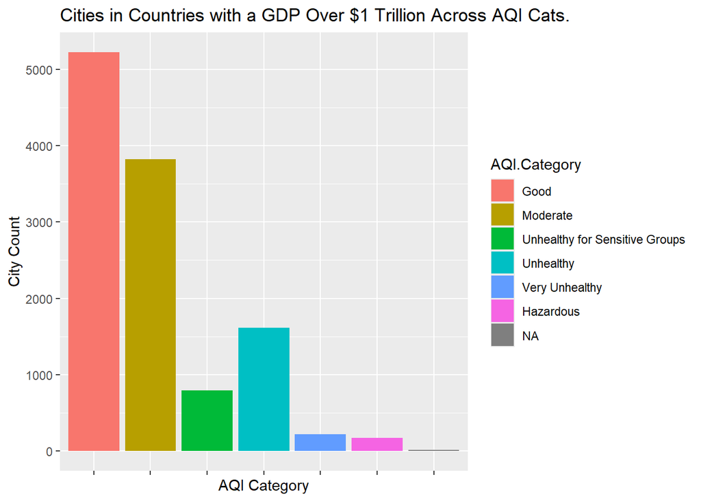

```r
library(ggplot2)
ggplot(gdp1t, aes(AQI.Category, fill = AQI.Category)) +
  geom_bar() +
  theme(axis.text.x = element_blank()) +
  labs(
    title = "Cities in Countries with a GDP Over $1 Trillion Across AQI Cats.",
    x = "AQI Category",
    y = "City Count"
  )
```

#### Description:

Our analysis of the one way table is visible in the bar graph, which represents the distribution of city AQI category in countries with a GDP over $1 trillion. I removed the categories from the x-axis and used fill by AQI category to make the graph easier to read.

Filter for Countries with a GDP under $1 trillion.

```r
gdput <- combined_data %>%
  filter(GDP < 1000)

gdput
```

```
## # A tibble: 6,718 × 17
##    Country       GDP Agriculture Industry Manufacturing Services City  AQI.Value
##    <chr>       <dbl>       <dbl>    <dbl>         <dbl>    <dbl> <chr>     <int>
##  1 Afghanistan  14.5        33.7     16.1          10.2       45 Kuhe…       151
##  2 Afghanistan  14.5        33.7     16.1          10.2       45 Qund…       117
##  3 Afghanistan  14.5        33.7     16.1          10.2       45 Rost…       113
##  4 Afghanistan  14.5        33.7     16.1          10.2       45 Tokz…        77
##  5 Afghanistan  14.5        33.7     16.1          10.2       45 Cari…        67
##  6 Afghanistan  14.5        33.7     16.1          10.2       45 Uruz…        57
##  7 Afghanistan  14.5        33.7     16.1          10.2       45 Herat        83
##  8 Afghanistan  14.5        33.7     16.1          10.2       45 Bagl…        72
##  9 Afghanistan  14.5        33.7     16.1          10.2       45 Anda…       104
## 10 Afghanistan  14.5        33.7     16.1          10.2       45 Nahr…        99
## # ℹ 6,708 more rows
## # ℹ 9 more variables: AQI.Category <fct>, CO.AQI.Value <int>,
## #   CO.AQI.Category <chr>, Ozone.AQI.Value <int>, Ozone.AQI.Category <chr>,
## #   NO2.AQI.Value <int>, NO2.AQI.Category <chr>, PM2.5.AQI.Value <int>,
## #   PM2.5.AQI.Category <chr>
```

Make a table of counts.

```r
tableAqi2 <- table(gdput$`AQI.Category`)
print(tableAqi2)
```

```
##
##                           Good                       Moderate
##                           2629                           2933
## Unhealthy for Sensitive Groups                      Unhealthy
##                            526                            501
##                 Very Unhealthy                      Hazardous
##                             57                             18
```

```r
library(knitr)
kable(tableAqi2, col.names = c('AQI Category', 'Count'),
      caption = "Distribution of Cities in Countries with a GDP Under $1 Trillion Across AQI Categories")
```

Distribution of Cities in Countries with a GDP Under $1 Trillion Across AQI Categories

| AQI Category | Count |
| --- | --- |
| Good | 2629 |
| Moderate | 2933 |
| Unhealthy for Sensitive Groups | 526 |
| Unhealthy | 501 |
| Very Unhealthy | 57 |
| Hazardous | 18 |

Make a table of marginal probabilities.

```r
ptableAqi2 <- prop.table(tableAqi2)
print(ptableAqi2)
```

```
##
##                           Good                       Moderate
##                    0.394507803                    0.440126050
## Unhealthy for Sensitive Groups                      Unhealthy
##                    0.078931573                    0.075180072
##                 Very Unhealthy                      Hazardous
##                    0.008553421                    0.002701080
```

```r
kable(ptableAqi2, col.names = c('AQI Category', 'Relative Frequency'),
      caption = "Probability Distribution of Cities in Countries with a GDP Under $1 Trillion Across AQI Categories")
```

Probability Distribution of Cities in Countries with a GDP Under $1 Trillion Across AQI Categories

| AQI Category | Relative Frequency |
| --- | --- |
| Good | 0.3945078 |
| Moderate | 0.4401261 |
| Unhealthy for Sensitive Groups | 0.0789316 |
| Unhealthy | 0.0751801 |
| Very Unhealthy | 0.0085534 |
| Hazardous | 0.0027011 |

#### Description:

Make a bar graph.

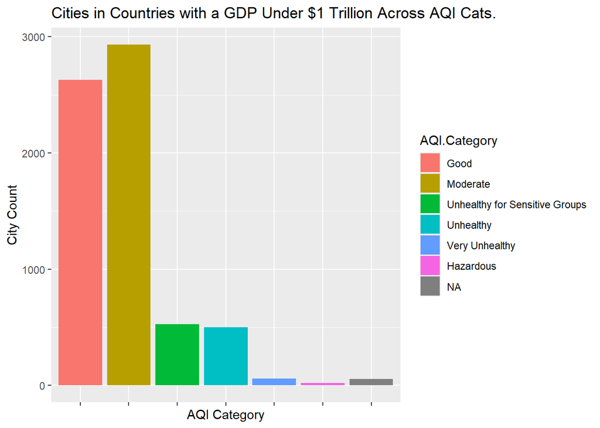

```r
ggplot(gdput, aes(`AQI.Category`, fill = `AQI.Category`)) +
  geom_bar() +
  theme(axis.text.x = element_blank()) +
  labs(
    title = "Cities in Countries with a GDP Under $1 Trillion Across AQI Cats.",
    x = "AQI Category",
    y = "City Count"
  )
```

#### Description:

The bar graph matches our analysis of the table; notice the shorter blue bar? I removed the categories from the x-axis and used fill by AQI category to make the graph easier to read.

Make a table comparing the number of cities in each AQI Category based on Countries with a GDP over $1 trillion.

```r
tableAqi3 <- table(gdp1t$Country,gdp1t$`AQI.Category`)
# additionally, remove rows with no data
tableAqi3 <- tableAqi3[rowSums(tableAqi3 != 0) > 0, ]
print(tableAqi3)
```

```
##
##                      Good Moderate Unhealthy for Sensitive Groups Unhealthy
##   Australia            78        4                              2         0
##   Brazil             1125      348                             39        44
##   Canada              101       40                              0         0
##   China                57      213                            183       294
##   France              414      352                             29         7
##   Germany             717      627                              1         0
##   India               130      585                            383      1101
##   Indonesia            76      179                             35        73
##   Italy               283      659                             35         2
##   Japan               432      254                             16         0
##   Mexico              140      279                             58        86
##   Netherlands         274       23                              1         0
##   Russian Federation 1025      203                             10         1
##   Saudi Arabia          0        3                              2         9
##   Spain               372       53                              0         0
##
##                      Very Unhealthy Hazardous
##   Australia                       1         0
##   Brazil                          6         0
##   Canada                          0         0
##   China                          45         3
##   France                          0         0
##   Germany                         0         0
##   India                         131       158
##   Indonesia                      16         0
##   Italy                           0         0
##   Japan                           0         0
##   Mexico                         19         6
##   Netherlands                     0         0
##   Russian Federation              1         1
##   Saudi Arabia                    0         0
##   Spain                           0         0
```

```r
kable(tableAqi3,
      caption = "Distribution of Cities Across AQI Categories based on Countries with a GDP Over $1 Trillion")
```

Distribution of Cities Across AQI Categories based on Countries with a GDP Over $1 Trillion

|  | Good | Moderate | Unhealthy for Sensitive Groups | Unhealthy | Very Unhealthy | Hazardous |
| --- | --- | --- | --- | --- | --- | --- |
| Australia | 78 | 4 | 2 | 0 | 1 | 0 |
| Brazil | 1125 | 348 | 39 | 44 | 6 | 0 |
| Canada | 101 | 40 | 0 | 0 | 0 | 0 |
| China | 57 | 213 | 183 | 294 | 45 | 3 |
| France | 414 | 352 | 29 | 7 | 0 | 0 |
| Germany | 717 | 627 | 1 | 0 | 0 | 0 |
| India | 130 | 585 | 383 | 1101 | 131 | 158 |
| Indonesia | 76 | 179 | 35 | 73 | 16 | 0 |
| Italy | 283 | 659 | 35 | 2 | 0 | 0 |
| Japan | 432 | 254 | 16 | 0 | 0 | 0 |
| Mexico | 140 | 279 | 58 | 86 | 19 | 6 |
| Netherlands | 274 | 23 | 1 | 0 | 0 | 0 |
| Russian Federation | 1025 | 203 | 10 | 1 | 1 | 1 |
| Saudi Arabia | 0 | 3 | 2 | 9 | 0 | 0 |
| Spain | 372 | 53 | 0 | 0 | 0 | 0 |

#### Description:

This two-way table shows the distribution of cities across AQI categories in cities with a GDP over $1 trillion. Brazil and the Russian Federation appear to have the most cities with a Good rating and India has the most cities with Hazardous, Very Unhealthy, Unhealthy, and Unhealthy for Sensitive Groups ratings. Columns = AQI Category rating Rows = Countries Counts = Cities

### Q2: How does the average AQI value vary among countries based on their primary GDP sector allocation (Agriculture, Industry, Manufacturing, Services)? (numeric variable across categorical variable)

Use mutate to create new variables (max_percentage and max_sector). Max_sector is a new categorical variable listing the sector with the highest percentage of GDP allocation (max_percentage) in its respective country.

```r
highest_section <- gdp %>%
  mutate(
    max_percentage = pmax(Industry, Services, Manufacturing, Agriculture, na.rm = TRUE),
    max_sector = case_when(
      max_percentage == Industry ~ "Industry",
      max_percentage == Services ~ "Services",
      max_percentage == Manufacturing ~ "Manufacturing",
      max_percentage == Agriculture ~ "Agriculture",
      TRUE ~ NA_character_
    )
  )

highest_section
```

```
## # A tibble: 222 × 8
##    Country        GDP Agriculture Industry Manufacturing Services max_percentage
##    <chr>        <dbl>       <dbl>    <dbl>         <dbl>    <dbl>          <dbl>
##  1 Afghanistan   14.5        33.7     16.1          10.2     45             45
##  2 Albania       23          18.3     21.2           5.9     48             48
##  3 Algeria      240.         13.2     38             7.8     45.1           45.1
##  4 American Sa…   0.9        NA       NA             8.7     NA              8.7
##  5 Andorra        3.7         0.5     11.4           3.6     78.6           78.6
##  6 Angola        84.7        14.9     45.3           8       39.7           45.3
##  7 Antigua and…   2           1.9     19.4           2.5     67.8           67.8
##  8 Argentina    641.          6.1     25.1          16.3     52.8           52.8
##  9 Armenia       24.2         8.4     23.9          11.1     59             59
## 10 Aruba          3.5        NA       NA            NA       NA             NA
## # ℹ 212 more rows
## # ℹ 1 more variable: max_sector <chr>
```

Create a new average AQI value column.

```r
averageAqi <- air %>%
  group_by(Country) %>%
  summarize(average_aqi = mean(AQI.Value, na.rm = TRUE))

averageAqi
```

```
## # A tibble: 176 × 2
##    Country       average_aqi
##    <chr>               <dbl>
##  1 ""                   54.0
##  2 "Afghanistan"        96.0
##  3 "Albania"            68.2
##  4 "Algeria"            88.2
##  5 "Andorra"            29.3
##  6 "Angola"             83.9
##  7 "Argentina"          28.2
##  8 "Armenia"            53.6
##  9 "Aruba"             163
## 10 "Australia"          33.6
## # ℹ 166 more rows
```

Join the two dataframes on Country.

```r
maxpAqi <- highest_section %>%
  left_join(averageAqi, by = "Country")

maxpAqi
```

```
## # A tibble: 222 × 9
##    Country        GDP Agriculture Industry Manufacturing Services max_percentage
##    <chr>        <dbl>       <dbl>    <dbl>         <dbl>    <dbl>          <dbl>
##  1 Afghanistan   14.5        33.7     16.1          10.2     45             45
##  2 Albania       23          18.3     21.2           5.9     48             48
##  3 Algeria      240.         13.2     38             7.8     45.1           45.1
##  4 American Sa…   0.9        NA       NA             8.7     NA              8.7
##  5 Andorra        3.7         0.5     11.4           3.6     78.6           78.6
##  6 Angola        84.7        14.9     45.3           8       39.7           45.3
##  7 Antigua and…   2           1.9     19.4           2.5     67.8           67.8
##  8 Argentina    641.          6.1     25.1          16.3     52.8           52.8
##  9 Armenia       24.2         8.4     23.9          11.1     59             59
## 10 Aruba          3.5        NA       NA            NA       NA             NA
## # ℹ 212 more rows
## # ℹ 2 more variables: max_sector <chr>, average_aqi <dbl>
```

Make a table of counts to see what the most popular maximum GDP allocation is.

```r
maxtable <- table(maxpAqi$max_sector)
print(maxtable)
```

```
##
##   Agriculture      Industry Manufacturing      Services
##             3            23             1           177
```

```r
kable(maxtable, caption = "Max GDP Allocation Sector")
```

Max GDP Allocation Sector

| Var1 | Freq |
| --- | --- |
| Agriculture | 3 |
| Industry | 23 |
| Manufacturing | 1 |
| Services | 177 |

#### Description:

This one-way table shows the most popular maximum GDP allocation among all countries. It appears that services is the most popular sector for countries to allocate the majority of their money towards.

Create a new variable based on average Country AQI values called aqi_category and make a new dataset.

```r
# breakpoints and labels
breaks <- c(-Inf, 50, 100, 150, 200, 300, Inf)
labels <- c("Good", "Moderate", "Unhealthy for Sensitive Groups", "Unhealthy", "Very Unhealthy", "Hazardous")

# make categories
aqi_categories <- cut(averageAqi$average_aqi, breaks = breaks, labels = labels, right = FALSE)

ranged_data <- data.frame(average_aqi = averageAqi$average_aqi, aqi_category = aqi_categories)
head(ranged_data)
```

```
##   average_aqi aqi_category
## 1    54.01171     Moderate
## 2    95.95918     Moderate
## 3    68.25000     Moderate
## 4    88.16667     Moderate
## 5    29.33333         Good
## 6    83.92593     Moderate
```

Join this new data with the max sector data on average AQI value.

```r
final <- maxpAqi %>%
  left_join(ranged_data, by = "average_aqi")
final
```

```
## # A tibble: 228 × 10
##    Country        GDP Agriculture Industry Manufacturing Services max_percentage
##    <chr>        <dbl>       <dbl>    <dbl>         <dbl>    <dbl>          <dbl>
##  1 Afghanistan   14.5        33.7     16.1          10.2     45             45
##  2 Albania       23          18.3     21.2           5.9     48             48
##  3 Algeria      240.         13.2     38             7.8     45.1           45.1
##  4 American Sa…   0.9        NA       NA             8.7     NA              8.7
##  5 Andorra        3.7         0.5     11.4           3.6     78.6           78.6
##  6 Angola        84.7        14.9     45.3           8       39.7           45.3
##  7 Antigua and…   2           1.9     19.4           2.5     67.8           67.8
##  8 Argentina    641.          6.1     25.1          16.3     52.8           52.8
##  9 Armenia       24.2         8.4     23.9          11.1     59             59
## 10 Aruba          3.5        NA       NA            NA       NA             NA
## # ℹ 218 more rows
## # ℹ 3 more variables: max_sector <chr>, average_aqi <dbl>, aqi_category <fct>
```

Get rid of NA values.

```r
final <- na.omit(final)

final
```

```
## # A tibble: 138 × 10
##    Country        GDP Agriculture Industry Manufacturing Services max_percentage
##    <chr>        <dbl>       <dbl>    <dbl>         <dbl>    <dbl>          <dbl>
##  1 Afghanistan   14.5        33.7     16.1          10.2     45             45
##  2 Albania       23          18.3     21.2           5.9     48             48
##  3 Algeria      240.         13.2     38             7.8     45.1           45.1
##  4 Andorra        3.7         0.5     11.4           3.6     78.6           78.6
##  5 Angola        84.7        14.9     45.3           8       39.7           45.3
##  6 Argentina    641.          6.1     25.1          16.3     52.8           52.8
##  7 Armenia       24.2         8.4     23.9          11.1     59             59
##  8 Australia   1724.          2.4     27.4           5.4     64.2           64.2
##  9 Austria      516           1.3     26.3          15.7     62.3           62.3
## 10 Azerbaijan    72.4         5.5     46.6           5.8     39.1           46.6
## # ℹ 128 more rows
## # ℹ 3 more variables: max_sector <chr>, average_aqi <dbl>, aqi_category <fct>
```

Make a bar graph.

[figure not shown]

```r
ggplot(final, aes(max_sector, fill = aqi_category)) +
  geom_bar(position = "fill") +
  labs(
    title = "Average Category vs. Max. Sector for GDPs Over $1 Trillion",
    x = "Sector With Highest GDP Allocation",
    y = "Percent of Countries")
```

#### Description:

This stacked bar graph shows the layout of average AQI category ratings based on countries’ maximum GDP sector allocations. It appears that over 50% percent of countries that allocate most of their GDP to agriculture have an average AQI rating of Moderate. It also appears that compared to other countries with other maximum sectors, countries that allocate most of their GDP to Industry have more Unhealthy ratings. I used position = fill in this graph so I could go off of percentages and see what percent of countries had what AQI rating based off of max sector.

###Q3: What are the most common max sectors across AQI Categories?

Rename factor levels for graphing.

```r
final <- final %>%
  mutate(aqi_category = recode(aqi_category, "Good" = "G", "Moderate" = "M", "Unhealthy for Sensitive Groups" = "USG", "Unhealthy" = "U", "Very Unhealthy" = "VU","Hazardous" = "H"))

final
```

```
## # A tibble: 138 × 10
##    Country        GDP Agriculture Industry Manufacturing Services max_percentage
##    <chr>        <dbl>       <dbl>    <dbl>         <dbl>    <dbl>          <dbl>
##  1 Afghanistan   14.5        33.7     16.1          10.2     45             45
##  2 Albania       23          18.3     21.2           5.9     48             48
##  3 Algeria      240.         13.2     38             7.8     45.1           45.1
##  4 Andorra        3.7         0.5     11.4           3.6     78.6           78.6
##  5 Angola        84.7        14.9     45.3           8       39.7           45.3
##  6 Argentina    641.          6.1     25.1          16.3     52.8           52.8
##  7 Armenia       24.2         8.4     23.9          11.1     59             59
##  8 Australia   1724.          2.4     27.4           5.4     64.2           64.2
##  9 Austria      516           1.3     26.3          15.7     62.3           62.3
## 10 Azerbaijan    72.4         5.5     46.6           5.8     39.1           46.6
## # ℹ 128 more rows
## # ℹ 3 more variables: max_sector <chr>, average_aqi <dbl>, aqi_category <fct>
```

Make a bar graph.

[figure not shown]

```r
ggplot(final, aes(aqi_category, fill = max_sector)) +
  geom_bar(position = "fill") +
  labs(
    title = "Max Sector vs. Average AQI (GDP Over $1 Trillion)",
    x = "Average AQI Category",
    y = "Percent of Countries")
```

#### Description:

This stacked bar graph shows the layout of maximum GDP sector allocations based on countries’ average AQI ratings. It seems to be a less meaningful graph since most of the max sectors are Services, but we can still glean some things. For example, it seems that countries with average AQI ratings of Unhealthy and Unhealthy for Sensitive Groups also appear at a higher percentage with max sectors in industry. I used position = fill in this graph so I could go off of percentages and see what percent of countries had what max sector based off average AQI Category. Clearly services is the most popular max sector.

### Q4: How does PM2.5 AQI category differ between cities in countries that allocate a higher percentage of their GDP to agriculture (over 20%) versus those that allocate a lower percentage?

Filter for countries with agriculture allocation over 20%.

```r
agriculture <- combined_data %>%
  select(Country, City, Agriculture, PM2.5.AQI.Category) %>%
  filter(Agriculture > 20)

agriculture
```

```
## # A tibble: 1,332 × 4
##    Country     City     Agriculture PM2.5.AQI.Category
##    <chr>       <chr>          <dbl> <chr>
##  1 Afghanistan Kuhestan        33.7 Unhealthy
##  2 Afghanistan Qunduz          33.7 Unhealthy for Sensitive Groups
##  3 Afghanistan Rostaq          33.7 Unhealthy for Sensitive Groups
##  4 Afghanistan Tokzar          33.7 Moderate
##  5 Afghanistan Carikar         33.7 Moderate
##  6 Afghanistan Uruzgan         33.7 Moderate
##  7 Afghanistan Herat           33.7 Moderate
##  8 Afghanistan Baglan          33.7 Moderate
##  9 Afghanistan Andarab         33.7 Unhealthy for Sensitive Groups
## 10 Afghanistan Nahrin          33.7 Moderate
## # ℹ 1,322 more rows
```

```r
overgood <- agriculture %>%
  filter(PM2.5.AQI.Category == "Good")
overgood
```

```
## # A tibble: 269 × 4
##    Country     City       Agriculture PM2.5.AQI.Category
##    <chr>       <chr>            <dbl> <chr>
##  1 Afghanistan Deh Rawud         33.7 Good
##  2 Benin       Malanville        25.4 Good
##  3 Benin       Lokossa           25.4 Good
##  4 Benin       Banikoara         25.4 Good
##  5 Benin       Bembereke         25.4 Good
##  6 Benin       Nikki             25.4 Good
##  7 Benin       Bassila           25.4 Good
##  8 Burundi     Ruyigi            25.2 Good
##  9 Burundi     Makamba           25.2 Good
## 10 Burundi     Karuzi            25.2 Good
## # ℹ 259 more rows
```

```r
overmod <- agriculture %>%
  filter(PM2.5.AQI.Category == "Moderate")
overmod
```

```
## # A tibble: 532 × 4
##    Country     City         Agriculture PM2.5.AQI.Category
##    <chr>       <chr>              <dbl> <chr>
##  1 Afghanistan Tokzar              33.7 Moderate
##  2 Afghanistan Carikar             33.7 Moderate
##  3 Afghanistan Uruzgan             33.7 Moderate
##  4 Afghanistan Herat               33.7 Moderate
##  5 Afghanistan Baglan              33.7 Moderate
##  6 Afghanistan Nahrin              33.7 Moderate
##  7 Afghanistan Sangin              33.7 Moderate
##  8 Afghanistan Baraki Barak        33.7 Moderate
##  9 Afghanistan Aybak               33.7 Moderate
## 10 Afghanistan Ciras               33.7 Moderate
## # ℹ 522 more rows
```

```r
#overgood:
#269/1332 = 0.201952 = 20.2%
#overmod:
#532/1332 = 0.3993994 = 39.94%
```

Create a table of counts.

```r
agriTable <- table(agriculture$Country, agriculture$PM2.5.AQI.Category)
# additionally, remove rows with no data
agriTable <- agriTable[rowSums(agriTable != 0) > 0, ]

agriTable
```

```
##
##                            Good Hazardous Moderate Unhealthy
##   Afghanistan                 1         0       30         5
##   Benin                       6         0       19         0
##   Burundi                     4         0        9         0
##   Cambodia                    8         0        4         0
##   Central African Republic    4         0       26         0
##   Chad                        5         0       21         2
##   Comoros                     3         0        0         0
##   Ethiopia                    9         0       56         5
##   Ghana                      18         0       34         1
##   Guinea                      7         0       11         2
##   Guinea-Bissau               0         0        0         1
##   Kenya                      17         0       31         6
##   Liberia                     7         0        2         0
##   Madagascar                 56         0        9         0
##   Malawi                     11         0       10         0
##   Mali                        6         0       12         3
##   Mozambique                 20         0        3         0
##   Myanmar                    44         0       14         0
##   Nepal                       1         0       12         6
##   Niger                       7         0       16         2
##   Nigeria                     2         0       89        21
##   Pakistan                    0        13       17       223
##   Rwanda                      0         0        9         2
##   Sierra Leone               10         0        5         0
##   Solomon Islands             1         0        0         0
##   Syrian Arab Republic        0         0       12         3
##   Tajikistan                  0         0        9         3
##   Uganda                      4         0       42         6
##   Uzbekistan                  0         0       21        13
##   Zimbabwe                   18         0        9         0
##
##                            Unhealthy for Sensitive Groups Very Unhealthy
##   Afghanistan                                          13              0
##   Benin                                                 2              0
##   Burundi                                               0              0
##   Cambodia                                              0              0
##   Central African Republic                              0              0
##   Chad                                                  5              0
```

[output cut: 9 more lines]

```
##   Mali                                                  4              0
##   Mozambique                                            0              0
##   Myanmar                                               1              0
##   Nepal                                                11              3
##   Niger                                                 4              0
##   Nigeria                                              29              3
##   Pakistan                                             33             21
##   Rwanda                                                2              0
##   Sierra Leone                                          0              0
##   Solomon Islands                                       0              0
##   Syrian Arab Republic                                  0              0
##   Tajikistan                                           17              0
##   Uganda                                               11              0
##   Uzbekistan                                           23              1
##   Zimbabwe                                              0              0
```

```r
kable(agriTable,
      caption = "PM2.5 Category Distribution of Cities With Over 20% of GDP Allocated to Agriculture")
```

PM2.5 Category Distribution of Cities With Over 20% of GDP Allocated to Agriculture

|  | Good | Hazardous | Moderate | Unhealthy | Unhealthy for Sensitive Groups | Very Unhealthy |
| --- | --- | --- | --- | --- | --- | --- |
| Afghanistan | 1 | 0 | 30 | 5 | 13 | 0 |
| Benin | 6 | 0 | 19 | 0 | 2 | 0 |
| Burundi | 4 | 0 | 9 | 0 | 0 | 0 |
| Cambodia | 8 | 0 | 4 | 0 | 0 | 0 |
| Central African Republic | 4 | 0 | 26 | 0 | 0 | 0 |
| Chad | 5 | 0 | 21 | 2 | 5 | 0 |
| Comoros | 3 | 0 | 0 | 0 | 0 | 0 |
| Ethiopia | 9 | 0 | 56 | 5 | 12 | 0 |
| Ghana | 18 | 0 | 34 | 1 | 5 | 0 |
| Guinea | 7 | 0 | 11 | 2 | 1 | 0 |
| Guinea-Bissau | 0 | 0 | 0 | 1 | 3 | 0 |
| Kenya | 17 | 0 | 31 | 6 | 6 | 0 |
| Liberia | 7 | 0 | 2 | 0 | 0 | 0 |
| Madagascar | 56 | 0 | 9 | 0 | 0 | 0 |
| Malawi | 11 | 0 | 10 | 0 | 0 | 0 |
| Mali | 6 | 0 | 12 | 3 | 4 | 0 |
| Mozambique | 20 | 0 | 3 | 0 | 0 | 0 |
| Myanmar | 44 | 0 | 14 | 0 | 1 | 0 |
| Nepal | 1 | 0 | 12 | 6 | 11 | 3 |
| Niger | 7 | 0 | 16 | 2 | 4 | 0 |
| Nigeria | 2 | 0 | 89 | 21 | 29 | 3 |
| Pakistan | 0 | 13 | 17 | 223 | 33 | 21 |
| Rwanda | 0 | 0 | 9 | 2 | 2 | 0 |
| Sierra Leone | 10 | 0 | 5 | 0 | 0 | 0 |
| Solomon Islands | 1 | 0 | 0 | 0 | 0 | 0 |
| Syrian Arab Republic | 0 | 0 | 12 | 3 | 0 | 0 |
| Tajikistan | 0 | 0 | 9 | 3 | 17 | 0 |
| Uganda | 4 | 0 | 42 | 6 | 11 | 0 |
| Uzbekistan | 0 | 0 | 21 | 13 | 23 | 1 |
| Zimbabwe | 18 | 0 | 9 | 0 | 0 | 0 |

Create a table of conditional probabilities.

```r
pagriTable <- prop.table(agriTable, margin = 1)
print(pagriTable)
```

```
##
##                                  Good  Hazardous   Moderate  Unhealthy
##   Afghanistan              0.02040816 0.00000000 0.61224490 0.10204082
##   Benin                    0.22222222 0.00000000 0.70370370 0.00000000
##   Burundi                  0.30769231 0.00000000 0.69230769 0.00000000
##   Cambodia                 0.66666667 0.00000000 0.33333333 0.00000000
##   Central African Republic 0.13333333 0.00000000 0.86666667 0.00000000
##   Chad                     0.15151515 0.00000000 0.63636364 0.06060606
##   Comoros                  1.00000000 0.00000000 0.00000000 0.00000000
##   Ethiopia                 0.10975610 0.00000000 0.68292683 0.06097561
##   Ghana                    0.31034483 0.00000000 0.58620690 0.01724138
##   Guinea                   0.33333333 0.00000000 0.52380952 0.09523810
##   Guinea-Bissau            0.00000000 0.00000000 0.00000000 0.25000000
##   Kenya                    0.28333333 0.00000000 0.51666667 0.10000000
##   Liberia                  0.77777778 0.00000000 0.22222222 0.00000000
##   Madagascar               0.86153846 0.00000000 0.13846154 0.00000000
##   Malawi                   0.52380952 0.00000000 0.47619048 0.00000000
##   Mali                     0.24000000 0.00000000 0.48000000 0.12000000
##   Mozambique               0.86956522 0.00000000 0.13043478 0.00000000
##   Myanmar                  0.74576271 0.00000000 0.23728814 0.00000000
##   Nepal                    0.03030303 0.00000000 0.36363636 0.18181818
##   Niger                    0.24137931 0.00000000 0.55172414 0.06896552
##   Nigeria                  0.01388889 0.00000000 0.61805556 0.14583333
##   Pakistan                 0.00000000 0.04234528 0.05537459 0.72638436
##   Rwanda                   0.00000000 0.00000000 0.69230769 0.15384615
##   Sierra Leone             0.66666667 0.00000000 0.33333333 0.00000000
##   Solomon Islands          1.00000000 0.00000000 0.00000000 0.00000000
##   Syrian Arab Republic     0.00000000 0.00000000 0.80000000 0.20000000
##   Tajikistan               0.00000000 0.00000000 0.31034483 0.10344828
##   Uganda                   0.06349206 0.00000000 0.66666667 0.09523810
##   Uzbekistan               0.00000000 0.00000000 0.36206897 0.22413793
##   Zimbabwe                 0.66666667 0.00000000 0.33333333 0.00000000
##
##                            Unhealthy for Sensitive Groups Very Unhealthy
##   Afghanistan                                  0.26530612     0.00000000
##   Benin                                        0.07407407     0.00000000
##   Burundi                                      0.00000000     0.00000000
##   Cambodia                                     0.00000000     0.00000000
##   Central African Republic                     0.00000000     0.00000000
##   Chad                                         0.15151515     0.00000000
```

[output cut: 9 more lines]

```
##   Mali                                         0.16000000     0.00000000
##   Mozambique                                   0.00000000     0.00000000
##   Myanmar                                      0.01694915     0.00000000
##   Nepal                                        0.33333333     0.09090909
##   Niger                                        0.13793103     0.00000000
##   Nigeria                                      0.20138889     0.02083333
##   Pakistan                                     0.10749186     0.06840391
##   Rwanda                                       0.15384615     0.00000000
##   Sierra Leone                                 0.00000000     0.00000000
##   Solomon Islands                              0.00000000     0.00000000
##   Syrian Arab Republic                         0.00000000     0.00000000
##   Tajikistan                                   0.58620690     0.00000000
##   Uganda                                       0.17460317     0.00000000
##   Uzbekistan                                   0.39655172     0.01724138
##   Zimbabwe                                     0.00000000     0.00000000
```

```r
kable(pagriTable,
      caption = "PM2.5 Category Distribution of Cities With Over 20% of GDP Allocated to Agriculture")
```

PM2.5 Category Distribution of Cities With Over 20% of GDP Allocated to Agriculture

|  | Good | Hazardous | Moderate | Unhealthy | Unhealthy for Sensitive Groups | Very Unhealthy |
| --- | --- | --- | --- | --- | --- | --- |
| Afghanistan | 0.0204082 | 0.0000000 | 0.6122449 | 0.1020408 | 0.2653061 | 0.0000000 |
| Benin | 0.2222222 | 0.0000000 | 0.7037037 | 0.0000000 | 0.0740741 | 0.0000000 |
| Burundi | 0.3076923 | 0.0000000 | 0.6923077 | 0.0000000 | 0.0000000 | 0.0000000 |
| Cambodia | 0.6666667 | 0.0000000 | 0.3333333 | 0.0000000 | 0.0000000 | 0.0000000 |
| Central African Republic | 0.1333333 | 0.0000000 | 0.8666667 | 0.0000000 | 0.0000000 | 0.0000000 |
| Chad | 0.1515152 | 0.0000000 | 0.6363636 | 0.0606061 | 0.1515152 | 0.0000000 |
| Comoros | 1.0000000 | 0.0000000 | 0.0000000 | 0.0000000 | 0.0000000 | 0.0000000 |
| Ethiopia | 0.1097561 | 0.0000000 | 0.6829268 | 0.0609756 | 0.1463415 | 0.0000000 |
| Ghana | 0.3103448 | 0.0000000 | 0.5862069 | 0.0172414 | 0.0862069 | 0.0000000 |
| Guinea | 0.3333333 | 0.0000000 | 0.5238095 | 0.0952381 | 0.0476190 | 0.0000000 |
| Guinea-Bissau | 0.0000000 | 0.0000000 | 0.0000000 | 0.2500000 | 0.7500000 | 0.0000000 |
| Kenya | 0.2833333 | 0.0000000 | 0.5166667 | 0.1000000 | 0.1000000 | 0.0000000 |
| Liberia | 0.7777778 | 0.0000000 | 0.2222222 | 0.0000000 | 0.0000000 | 0.0000000 |
| Madagascar | 0.8615385 | 0.0000000 | 0.1384615 | 0.0000000 | 0.0000000 | 0.0000000 |
| Malawi | 0.5238095 | 0.0000000 | 0.4761905 | 0.0000000 | 0.0000000 | 0.0000000 |
| Mali | 0.2400000 | 0.0000000 | 0.4800000 | 0.1200000 | 0.1600000 | 0.0000000 |
| Mozambique | 0.8695652 | 0.0000000 | 0.1304348 | 0.0000000 | 0.0000000 | 0.0000000 |
| Myanmar | 0.7457627 | 0.0000000 | 0.2372881 | 0.0000000 | 0.0169492 | 0.0000000 |
| Nepal | 0.0303030 | 0.0000000 | 0.3636364 | 0.1818182 | 0.3333333 | 0.0909091 |
| Niger | 0.2413793 | 0.0000000 | 0.5517241 | 0.0689655 | 0.1379310 | 0.0000000 |
| Nigeria | 0.0138889 | 0.0000000 | 0.6180556 | 0.1458333 | 0.2013889 | 0.0208333 |
| Pakistan | 0.0000000 | 0.0423453 | 0.0553746 | 0.7263844 | 0.1074919 | 0.0684039 |
| Rwanda | 0.0000000 | 0.0000000 | 0.6923077 | 0.1538462 | 0.1538462 | 0.0000000 |
| Sierra Leone | 0.6666667 | 0.0000000 | 0.3333333 | 0.0000000 | 0.0000000 | 0.0000000 |
| Solomon Islands | 1.0000000 | 0.0000000 | 0.0000000 | 0.0000000 | 0.0000000 | 0.0000000 |
| Syrian Arab Republic | 0.0000000 | 0.0000000 | 0.8000000 | 0.2000000 | 0.0000000 | 0.0000000 |
| Tajikistan | 0.0000000 | 0.0000000 | 0.3103448 | 0.1034483 | 0.5862069 | 0.0000000 |
| Uganda | 0.0634921 | 0.0000000 | 0.6666667 | 0.0952381 | 0.1746032 | 0.0000000 |
| Uzbekistan | 0.0000000 | 0.0000000 | 0.3620690 | 0.2241379 | 0.3965517 | 0.0172414 |
| Zimbabwe | 0.6666667 | 0.0000000 | 0.3333333 | 0.0000000 | 0.0000000 | 0.0000000 |

#### Description:

These two-way tables are a little ugly, but the probability tables are conditional by row, meaning they add up across rows. For example, approximately 61% of the Aphgan cities in this dataset have Moderate AQI ratings for PM2.5 levels.

Reorder factor levels.

```r
agriculture$PM2.5.AQI.Category <- factor(agriculture$PM2.5.AQI.Category,
                              levels = c("Good", "Moderate", "Unhealthy for Sensitive Groups", "Unhealthy", "Very Unhealthy", "Hazardous"))
```

Rename factor levels for graphing.

```r
agriculture <- agriculture %>%
  mutate(PM2.5.AQI.Category = recode(PM2.5.AQI.Category, "Good" = "G", "Moderate" = "M", "Unhealthy for Sensitive Groups" = "USG", "Unhealthy" = "U", "Very Unhealthy" = "VU","Hazardous" = "H"))

agriculture
```

```
## # A tibble: 1,332 × 4
##    Country     City     Agriculture PM2.5.AQI.Category
##    <chr>       <chr>          <dbl> <fct>
##  1 Afghanistan Kuhestan        33.7 U
##  2 Afghanistan Qunduz          33.7 USG
##  3 Afghanistan Rostaq          33.7 USG
##  4 Afghanistan Tokzar          33.7 M
##  5 Afghanistan Carikar         33.7 M
##  6 Afghanistan Uruzgan         33.7 M
##  7 Afghanistan Herat           33.7 M
##  8 Afghanistan Baglan          33.7 M
##  9 Afghanistan Andarab         33.7 USG
## 10 Afghanistan Nahrin          33.7 M
## # ℹ 1,322 more rows
```

Make a bar graph. (Had to replace fill = Country with fill = PM2.5.AQI.Category in aesthetics because there were too many Countries).

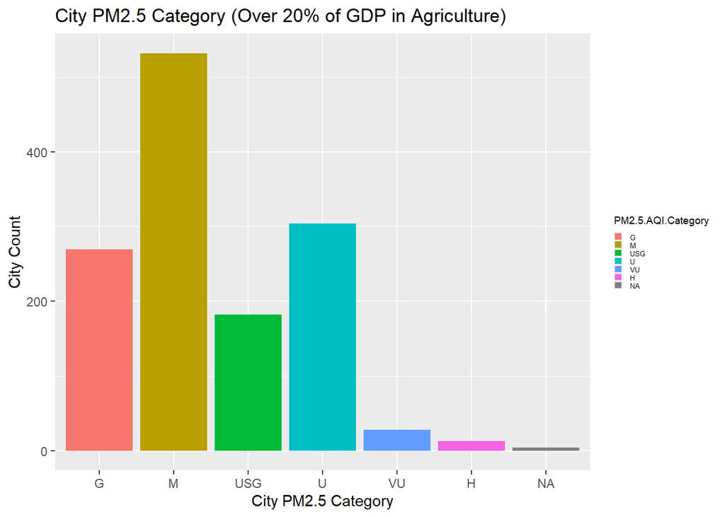

```r
ggplot(agriculture, aes(PM2.5.AQI.Category, fill = PM2.5.AQI.Category)) +
  geom_bar() +
  theme(
    legend.text = element_text(size=5),
    legend.title = element_text(size=7),
    legend.key.size = unit(0.2, "cm")
  ) +
  labs(
    title = "City PM2.5 Category (Over 20% of GDP in Agriculture)",
    x = "City PM2.5 Category",
    y = "City Count",
  )
```

#### Description:

This stacked bar graph represents the distribution of cities among particulate matter 2.5 (PM2.5) Categories for countries with over 20% of their GDP allocated to agriculture.

Filter for countries with agriculture allocation under 20%.

```r
agricultureU <- combined_data %>%
  select(Country, City, Agriculture, PM2.5.AQI.Category) %>%
  filter(Agriculture < 20)

agricultureU
```

```
## # A tibble: 17,167 × 4
##    Country City    Agriculture PM2.5.AQI.Category
##    <chr>   <chr>         <dbl> <chr>
##  1 Albania Gramsh         18.3 Moderate
##  2 Albania Elbasan        18.3 Moderate
##  3 Albania Tirana         18.3 Moderate
##  4 Albania Cerrik         18.3 Moderate
##  5 Albania Lushnje        18.3 Moderate
##  6 Albania Berat          18.3 Moderate
##  7 Albania Fier           18.3 Moderate
##  8 Albania Shkoder        18.3 Moderate
##  9 Albania Bulqize        18.3 Moderate
## 10 Albania Kukes          18.3 Moderate
## # ℹ 17,157 more rows
```

Create a table of counts.

```r
undTable <- table(agricultureU$Country, agricultureU$PM2.5.AQI.Category)
# additionally, remove rows with no data
undTable <- undTable[rowSums(undTable != 0) > 0, ]
print(undTable)
```

```
##
##                          Good Hazardous Moderate Unhealthy
##   Albania                   2         0       28         0
##   Algeria                   4         0        4         2
##   Andorra                   3         0        0         0
##   Angola                   10         0        9         4
##   Argentina                61         0        6         0
##   Armenia                  10         0       11         0
##   Australia                78         0        4         0
##   Austria                  21         0       47         0
##   Azerbaijan               11         0       27         0
##   Bahrain                   0         0        0         1
##   Bangladesh                4         0       36        26
##   Barbados                  0         0        1         0
##   Belarus                  19         0        3         0
##   Belgium                 203         0       81         0
##   Belize                    1         0        2         0
##   Bhutan                    2         0        0         0
##   Bosnia and Herzegovina    9         0       26         0
##   Botswana                 13         0        6         0
##   Brazil                 1125         0      348        44
##   Bulgaria                 32         0       33         0
##   Burkina Faso             17         0       17         0
##   Cabo Verde                2         0        0         0
##   Cameroon                 12         0       45         0
##   Chile                    36         1       19        14
##   China                    63         2      294       219
##   Colombia                 73         0      143         1
##   Costa Rica                9         0       29         0
##   Croatia                  11         0       20         0
##   Cuba                     27         0       63         0
##   Cyprus                    4         0        2         0
##   Czechia                  32         0       95         0
##   Denmark                  59         0        1         0
##   Dominican Republic        1         0       12         9
##   Ecuador                  39         0       26         0
##   El Salvador               0         0       17         2
##   Equatorial Guinea         2         0        2         0
##   Estonia                  11         0        1         0
##   Finland                  76         0        2         3
```

[output cut: 179 more lines]

```
##   Sri Lanka                                           2              0
##   Sudan                                               3              0
##   Suriname                                            0              0
##   Sweden                                              0              0
##   Switzerland                                         9              0
##   Thailand                                           11              0
##   Togo                                                1              0
##   Trinidad and Tobago                                 1              0
##   Tunisia                                             6              0
##   Turkmenistan                                        9              0
##   Ukraine                                             2              0
##   United Arab Emirates                                0              0
##   Uruguay                                             0              0
##   Viet Nam                                            7              0
##   Zambia                                              1              0
```

```r
kable(undTable,
      caption = "PM2.5 Category Distribution of Cities With Under 20% of GDP Allocated to Agriculture")
```

PM2.5 Category Distribution of Cities With Under 20% of GDP Allocated to Agriculture

|  | Good | Hazardous | Moderate | Unhealthy | Unhealthy for Sensitive Groups | Very Unhealthy |
| --- | --- | --- | --- | --- | --- | --- |
| Albania | 2 | 0 | 28 | 0 | 2 | 0 |
| Algeria | 4 | 0 | 4 | 2 | 2 | 0 |
| Andorra | 3 | 0 | 0 | 0 | 0 | 0 |
| Angola | 10 | 0 | 9 | 4 | 3 | 1 |
| Argentina | 61 | 0 | 6 | 0 | 1 | 0 |
| Armenia | 10 | 0 | 11 | 0 | 1 | 0 |
| Australia | 78 | 0 | 4 | 0 | 2 | 1 |
| Austria | 21 | 0 | 47 | 0 | 0 | 0 |
| Azerbaijan | 11 | 0 | 27 | 0 | 0 | 0 |
| Bahrain | 0 | 0 | 0 | 1 | 0 | 0 |
| Bangladesh | 4 | 0 | 36 | 26 | 12 | 2 |
| Barbados | 0 | 0 | 1 | 0 | 0 | 0 |
| Belarus | 19 | 0 | 3 | 0 | 0 | 0 |
| Belgium | 203 | 0 | 81 | 0 | 0 | 0 |
| Belize | 1 | 0 | 2 | 0 | 0 | 0 |
| Bhutan | 2 | 0 | 0 | 0 | 0 | 0 |
| Bosnia and Herzegovina | 9 | 0 | 26 | 0 | 1 | 0 |
| Botswana | 13 | 0 | 6 | 0 | 0 | 0 |
| Brazil | 1125 | 0 | 348 | 44 | 39 | 6 |
| Bulgaria | 32 | 0 | 33 | 0 | 0 | 0 |
| Burkina Faso | 17 | 0 | 17 | 0 | 0 | 0 |
| Cabo Verde | 2 | 0 | 0 | 0 | 0 | 0 |
| Cameroon | 12 | 0 | 45 | 0 | 7 | 0 |
| Chile | 36 | 1 | 19 | 14 | 7 | 4 |
| China | 63 | 2 | 294 | 219 | 206 | 11 |
| Colombia | 73 | 0 | 143 | 1 | 33 | 0 |
| Costa Rica | 9 | 0 | 29 | 0 | 0 | 0 |
| Croatia | 11 | 0 | 20 | 0 | 0 | 0 |
| Cuba | 27 | 0 | 63 | 0 | 8 | 0 |
| Cyprus | 4 | 0 | 2 | 0 | 0 | 0 |

[output cut: 85 more lines]

Create a table of conditional probabilities.

```r
pundTable <- prop.table(undTable, margin = 1)
print(pundTable)
```

```
##
##                                  Good    Hazardous     Moderate    Unhealthy
##   Albania                0.0625000000 0.0000000000 0.8750000000 0.0000000000
##   Algeria                0.3333333333 0.0000000000 0.3333333333 0.1666666667
##   Andorra                1.0000000000 0.0000000000 0.0000000000 0.0000000000
##   Angola                 0.3703703704 0.0000000000 0.3333333333 0.1481481481
##   Argentina              0.8970588235 0.0000000000 0.0882352941 0.0000000000
##   Armenia                0.4545454545 0.0000000000 0.5000000000 0.0000000000
##   Australia              0.9176470588 0.0000000000 0.0470588235 0.0000000000
##   Austria                0.3088235294 0.0000000000 0.6911764706 0.0000000000
##   Azerbaijan             0.2894736842 0.0000000000 0.7105263158 0.0000000000
##   Bahrain                0.0000000000 0.0000000000 0.0000000000 1.0000000000
##   Bangladesh             0.0500000000 0.0000000000 0.4500000000 0.3250000000
##   Barbados               0.0000000000 0.0000000000 1.0000000000 0.0000000000
##   Belarus                0.8636363636 0.0000000000 0.1363636364 0.0000000000
##   Belgium                0.7147887324 0.0000000000 0.2852112676 0.0000000000
##   Belize                 0.3333333333 0.0000000000 0.6666666667 0.0000000000
##   Bhutan                 1.0000000000 0.0000000000 0.0000000000 0.0000000000
##   Bosnia and Herzegovina 0.2500000000 0.0000000000 0.7222222222 0.0000000000
##   Botswana               0.6842105263 0.0000000000 0.3157894737 0.0000000000
##   Brazil                 0.7202304738 0.0000000000 0.2227912932 0.0281690141
##   Bulgaria               0.4923076923 0.0000000000 0.5076923077 0.0000000000
##   Burkina Faso           0.5000000000 0.0000000000 0.5000000000 0.0000000000
##   Cabo Verde             1.0000000000 0.0000000000 0.0000000000 0.0000000000
##   Cameroon               0.1875000000 0.0000000000 0.7031250000 0.0000000000
##   Chile                  0.4444444444 0.0123456790 0.2345679012 0.1728395062
##   China                  0.0792452830 0.0025157233 0.3698113208 0.2754716981
##   Colombia               0.2920000000 0.0000000000 0.5720000000 0.0040000000
##   Costa Rica             0.2368421053 0.0000000000 0.7631578947 0.0000000000
##   Croatia                0.3548387097 0.0000000000 0.6451612903 0.0000000000
##   Cuba                   0.2755102041 0.0000000000 0.6428571429 0.0000000000
##   Cyprus                 0.6666666667 0.0000000000 0.3333333333 0.0000000000
##   Czechia                0.2519685039 0.0000000000 0.7480314961 0.0000000000
##   Denmark                0.9833333333 0.0000000000 0.0166666667 0.0000000000
##   Dominican Republic     0.0263157895 0.0000000000 0.3157894737 0.2368421053
##   Ecuador                0.5909090909 0.0000000000 0.3939393939 0.0000000000
##   El Salvador            0.0000000000 0.0000000000 0.5151515152 0.0606060606
##   Equatorial Guinea      0.5000000000 0.0000000000 0.5000000000 0.0000000000
##   Estonia                0.9166666667 0.0000000000 0.0833333333 0.0000000000
##   Finland                0.9382716049 0.0000000000 0.0246913580 0.0370370370
```

[output cut: 179 more lines]

```
##   Sri Lanka                                0.0434782609   0.0000000000
##   Sudan                                    0.1071428571   0.0000000000
##   Suriname                                 0.0000000000   0.0000000000
##   Sweden                                   0.0000000000   0.0000000000
##   Switzerland                              0.0775862069   0.0000000000
##   Thailand                                 0.0447154472   0.0000000000
##   Togo                                     0.0526315789   0.0000000000
##   Trinidad and Tobago                      0.1250000000   0.0000000000
##   Tunisia                                  0.1363636364   0.0000000000
##   Turkmenistan                             0.5000000000   0.0000000000
##   Ukraine                                  0.0091324201   0.0000000000
##   United Arab Emirates                     0.0000000000   0.0000000000
##   Uruguay                                  0.0000000000   0.0000000000
##   Viet Nam                                 0.1166666667   0.0000000000
##   Zambia                                   0.0238095238   0.0000000000
```

```r
kable(pundTable,
      caption = "PM2.5 Category Distribution of Cities With Under 20% of GDP Allocated to Agriculture")
```

PM2.5 Category Distribution of Cities With Under 20% of GDP Allocated to Agriculture

|  | Good | Hazardous | Moderate | Unhealthy | Unhealthy for Sensitive Groups | Very Unhealthy |
| --- | --- | --- | --- | --- | --- | --- |
| Albania | 0.0625000 | 0.0000000 | 0.8750000 | 0.0000000 | 0.0625000 | 0.0000000 |
| Algeria | 0.3333333 | 0.0000000 | 0.3333333 | 0.1666667 | 0.1666667 | 0.0000000 |
| Andorra | 1.0000000 | 0.0000000 | 0.0000000 | 0.0000000 | 0.0000000 | 0.0000000 |
| Angola | 0.3703704 | 0.0000000 | 0.3333333 | 0.1481481 | 0.1111111 | 0.0370370 |
| Argentina | 0.8970588 | 0.0000000 | 0.0882353 | 0.0000000 | 0.0147059 | 0.0000000 |
| Armenia | 0.4545455 | 0.0000000 | 0.5000000 | 0.0000000 | 0.0454545 | 0.0000000 |
| Australia | 0.9176471 | 0.0000000 | 0.0470588 | 0.0000000 | 0.0235294 | 0.0117647 |
| Austria | 0.3088235 | 0.0000000 | 0.6911765 | 0.0000000 | 0.0000000 | 0.0000000 |
| Azerbaijan | 0.2894737 | 0.0000000 | 0.7105263 | 0.0000000 | 0.0000000 | 0.0000000 |
| Bahrain | 0.0000000 | 0.0000000 | 0.0000000 | 1.0000000 | 0.0000000 | 0.0000000 |
| Bangladesh | 0.0500000 | 0.0000000 | 0.4500000 | 0.3250000 | 0.1500000 | 0.0250000 |
| Barbados | 0.0000000 | 0.0000000 | 1.0000000 | 0.0000000 | 0.0000000 | 0.0000000 |
| Belarus | 0.8636364 | 0.0000000 | 0.1363636 | 0.0000000 | 0.0000000 | 0.0000000 |
| Belgium | 0.7147887 | 0.0000000 | 0.2852113 | 0.0000000 | 0.0000000 | 0.0000000 |
| Belize | 0.3333333 | 0.0000000 | 0.6666667 | 0.0000000 | 0.0000000 | 0.0000000 |
| Bhutan | 1.0000000 | 0.0000000 | 0.0000000 | 0.0000000 | 0.0000000 | 0.0000000 |
| Bosnia and Herzegovina | 0.2500000 | 0.0000000 | 0.7222222 | 0.0000000 | 0.0277778 | 0.0000000 |
| Botswana | 0.6842105 | 0.0000000 | 0.3157895 | 0.0000000 | 0.0000000 | 0.0000000 |
| Brazil | 0.7202305 | 0.0000000 | 0.2227913 | 0.0281690 | 0.0249680 | 0.0038412 |
| Bulgaria | 0.4923077 | 0.0000000 | 0.5076923 | 0.0000000 | 0.0000000 | 0.0000000 |
| Burkina Faso | 0.5000000 | 0.0000000 | 0.5000000 | 0.0000000 | 0.0000000 | 0.0000000 |
| Cabo Verde | 1.0000000 | 0.0000000 | 0.0000000 | 0.0000000 | 0.0000000 | 0.0000000 |
| Cameroon | 0.1875000 | 0.0000000 | 0.7031250 | 0.0000000 | 0.1093750 | 0.0000000 |
| Chile | 0.4444444 | 0.0123457 | 0.2345679 | 0.1728395 | 0.0864198 | 0.0493827 |
| China | 0.0792453 | 0.0025157 | 0.3698113 | 0.2754717 | 0.2591195 | 0.0138365 |
| Colombia | 0.2920000 | 0.0000000 | 0.5720000 | 0.0040000 | 0.1320000 | 0.0000000 |
| Costa Rica | 0.2368421 | 0.0000000 | 0.7631579 | 0.0000000 | 0.0000000 | 0.0000000 |
| Croatia | 0.3548387 | 0.0000000 | 0.6451613 | 0.0000000 | 0.0000000 | 0.0000000 |
| Cuba | 0.2755102 | 0.0000000 | 0.6428571 | 0.0000000 | 0.0816327 | 0.0000000 |
| Cyprus | 0.6666667 | 0.0000000 | 0.3333333 | 0.0000000 | 0.0000000 | 0.0000000 |

[output cut: 85 more lines]

#### Description:

These two-way tables are once again a little ugly, but the probability tables are conditional by row, meaning they add up across rows. For example, approximately 88% of the Albanian cities in this dataset have Moderate AQI ratings for PM2.5 levels.

Reorder factor levels.

```r
agricultureU$PM2.5.AQI.Category<- factor(agricultureU$PM2.5.AQI.Category,
                              levels = c("Good", "Moderate", "Unhealthy for Sensitive Groups", "Unhealthy", "Very Unhealthy", "Hazardous"))
```

Rename factor levels for graphing.

```r
agricultureU <- agricultureU %>%
  mutate(PM2.5.AQI.Category = recode(PM2.5.AQI.Category, "Good" = "G", "Moderate" = "M", "Unhealthy for Sensitive Groups" = "USG", "Unhealthy" = "U", "Very Unhealthy" = "VU","Hazardous" = "H"))

agricultureU
```

```
## # A tibble: 17,167 × 4
##    Country City    Agriculture PM2.5.AQI.Category
##    <chr>   <chr>         <dbl> <fct>
##  1 Albania Gramsh         18.3 M
##  2 Albania Elbasan        18.3 M
##  3 Albania Tirana         18.3 M
##  4 Albania Cerrik         18.3 M
##  5 Albania Lushnje        18.3 M
##  6 Albania Berat          18.3 M
##  7 Albania Fier           18.3 M
##  8 Albania Shkoder        18.3 M
##  9 Albania Bulqize        18.3 M
## 10 Albania Kukes          18.3 M
## # ℹ 17,157 more rows
```

```r
undergood <- agricultureU %>%
  filter(PM2.5.AQI.Category == "G")
head(undergood)
```

```
## # A tibble: 6 × 4
##   Country City     Agriculture PM2.5.AQI.Category
##   <chr>   <chr>          <dbl> <fct>
## 1 Albania Korce           18.3 G
## 2 Albania Pogradec        18.3 G
## 3 Algeria Wahran          13.2 G
## 4 Algeria Sidi Ali        13.2 G
## 5 Algeria Birin           13.2 G
## 6 Algeria Aflu            13.2 G
```

```r
undermod <- agricultureU %>%
  filter(PM2.5.AQI.Category == "M")
head(undermod)
```

```
## # A tibble: 6 × 4
##   Country City    Agriculture PM2.5.AQI.Category
##   <chr>   <chr>         <dbl> <fct>
## 1 Albania Gramsh         18.3 M
## 2 Albania Elbasan        18.3 M
## 3 Albania Tirana         18.3 M
## 4 Albania Cerrik         18.3 M
## 5 Albania Lushnje        18.3 M
## 6 Albania Berat          18.3 M
```

```r
#undergood:
#7700/17167 = 0.448535 = 44.85%
#undermod:
#6150/17167 = 0.3582455 = 35.82%
```

Make a bar graph. (Had to once again replace fill = Country with fill = PM2.5.AQI.Category in aesthetics because there were too many Countries).

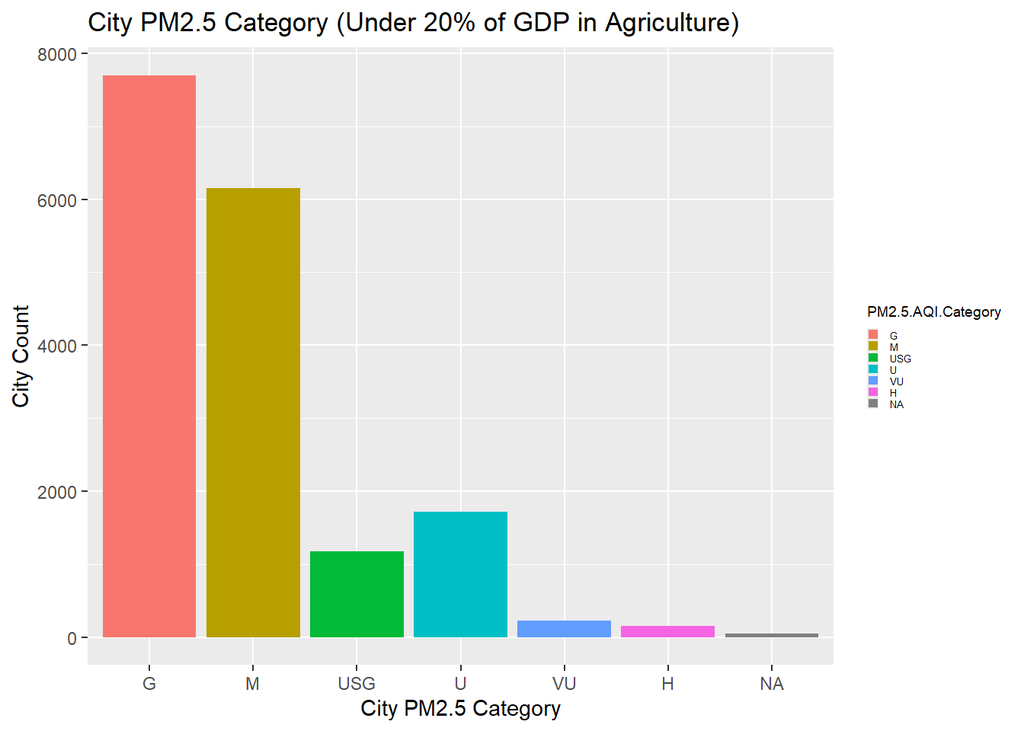

```r
ggplot(agricultureU, aes(PM2.5.AQI.Category, fill = PM2.5.AQI.Category)) +
  geom_bar() +
  theme(
    legend.text = element_text(size=5),
    legend.title = element_text(size=7),
    legend.key.size = unit(0.2, "cm")
  ) +
  labs(
    title = "City PM2.5 Category (Under 20% of GDP in Agriculture)",
    x = "City PM2.5 Category",
    y = "City Count",
  )
```

#### Description:

This stacked bar graph represents the distribution of cities among particulate matter 2.5 (PM2.5) Categories for countries with under 20% of their GDP allocated to agriculture. There seems to be (most notably) a higher frequency of Good ratings and a lower frequency of Unhealthy ratings in this bar graph than that of the bar graph representing countries with agricultural GDP allocation over 20%.

# Milestone #5

### Q1: Is there a correlation between overall GDP and a country’s average AQI value? (2 numeric variables)

Filter non-countries.

```r
gdp <- gdp %>%
  filter(!if_any(everything(), is.na), !Country %in% c("World", "East Asia & Pacific", "Europe & Central Asia", "Latin America & Caribbean", "Middle East & North Africa", "North America", "South Asia", "Sub-Saharan Africa")) %>%
  arrange(desc(GDP))

gdp
```

```
## # A tibble: 179 × 6
##    Country               GDP Agriculture Industry Manufacturing Services
##    <chr>               <dbl>       <dbl>    <dbl>         <dbl>    <dbl>
##  1 United States      27361.         0.9     17.7          10.6     76.7
##  2 China              17795.         7.1     38.3          26.2     54.6
##  3 Germany             4456.         0.7     28.1          19       62.6
##  4 Japan               4213.         1       26.9          19.2     71.4
##  5 India               3550.        16       25            12.8     49.8
##  6 United Kingdom      3340          0.7     16.9           8.5     72.8
##  7 France              3031.         1.9     18.7           9.7     69.2
##  8 Italy               2255.         1.9     23.1          15.7     64.9
##  9 Brazil              2174.         6.2     22.3          13.3     58.9
## 10 Russian Federation  2021.         3.3     30.6          12.4     56.9
## # ℹ 169 more rows
```

Filter for Countries with a GDP over $1 trillion.

```r
gdp1t <- gdp %>%
  filter(GDP > 1000)

gdp1t
```

```
## # A tibble: 18 × 6
##    Country               GDP Agriculture Industry Manufacturing Services
##    <chr>               <dbl>       <dbl>    <dbl>         <dbl>    <dbl>
##  1 United States      27361.         0.9     17.7          10.6     76.7
##  2 China              17795.         7.1     38.3          26.2     54.6
##  3 Germany             4456.         0.7     28.1          19       62.6
##  4 Japan               4213.         1       26.9          19.2     71.4
##  5 India               3550.        16       25            12.8     49.8
##  6 United Kingdom      3340          0.7     16.9           8.5     72.8
##  7 France              3031.         1.9     18.7           9.7     69.2
##  8 Italy               2255.         1.9     23.1          15.7     64.9
##  9 Brazil              2174.         6.2     22.3          13.3     58.9
## 10 Russian Federation  2021.         3.3     30.6          12.4     56.9
## 11 Mexico              1789.         4       31.8          20.2     58.3
## 12 Australia           1724.         2.4     27.4           5.4     64.2
## 13 Korea, Rep.         1713.         1.6     31.6          24.3     58.4
## 14 Spain               1581.         2.3     20.2          11.5     68.5
## 15 Indonesia           1371.        12.5     40.2          18.7     42.9
## 16 Netherlands         1118.         1.5     19.4          11.6     69.3
## 17 Turkiye             1108          6.2     28.3          19.4     54
## 18 Saudi Arabia        1068.         2.7     47            14.8     44.9
```

Create a new average AQI value column.

```r
averageAqi <- air %>%
  group_by(Country) %>%
  summarize(average_aqi = mean(AQI.Value, na.rm = TRUE))

averageAqi
```

```
## # A tibble: 176 × 2
##    Country       average_aqi
##    <chr>               <dbl>
##  1 ""                   54.0
##  2 "Afghanistan"        96.0
##  3 "Albania"            68.2
##  4 "Algeria"            88.2
##  5 "Andorra"            29.3
##  6 "Angola"             83.9
##  7 "Argentina"          28.2
##  8 "Armenia"            53.6
##  9 "Aruba"             163
## 10 "Australia"          33.6
## # ℹ 166 more rows
```

Join the two dataframes on Country and get rid of NA values

```r
avg1t <- gdp1t %>%
  left_join(averageAqi, by = "Country") %>%
  filter(!is.na(average_aqi))

avg1t
```

```
## # A tibble: 14 × 7
##    Country           GDP Agriculture Industry Manufacturing Services average_aqi
##    <chr>           <dbl>       <dbl>    <dbl>         <dbl>    <dbl>       <dbl>
##  1 China          17795.         7.1     38.3          26.2     54.6       127.
##  2 Germany         4456.         0.7     28.1          19       62.6        48.2
##  3 Japan           4213.         1       26.9          19.2     71.4        51.7
##  4 India           3550.        16       25            12.8     49.8       153.
##  5 France          3031.         1.9     18.7           9.7     69.2        53.3
##  6 Italy           2255.         1.9     23.1          15.7     64.9        62.0
##  7 Brazil          2174.         6.2     22.3          13.3     58.9        44.6
##  8 Russian Feder…  2021.         3.3     30.6          12.4     56.9        42.5
##  9 Mexico          1789.         4       31.8          20.2     58.3        89.5
## 10 Australia       1724.         2.4     27.4           5.4     64.2        33.6
## 11 Spain           1581.         2.3     20.2          11.5     68.5        38.5
## 12 Indonesia       1371.        12.5     40.2          18.7     42.9        93.0
## 13 Netherlands     1118.         1.5     19.4          11.6     69.3        38.1
## 14 Saudi Arabia    1068.         2.7     47            14.8     44.9       149.
```

Make a bopxplot.

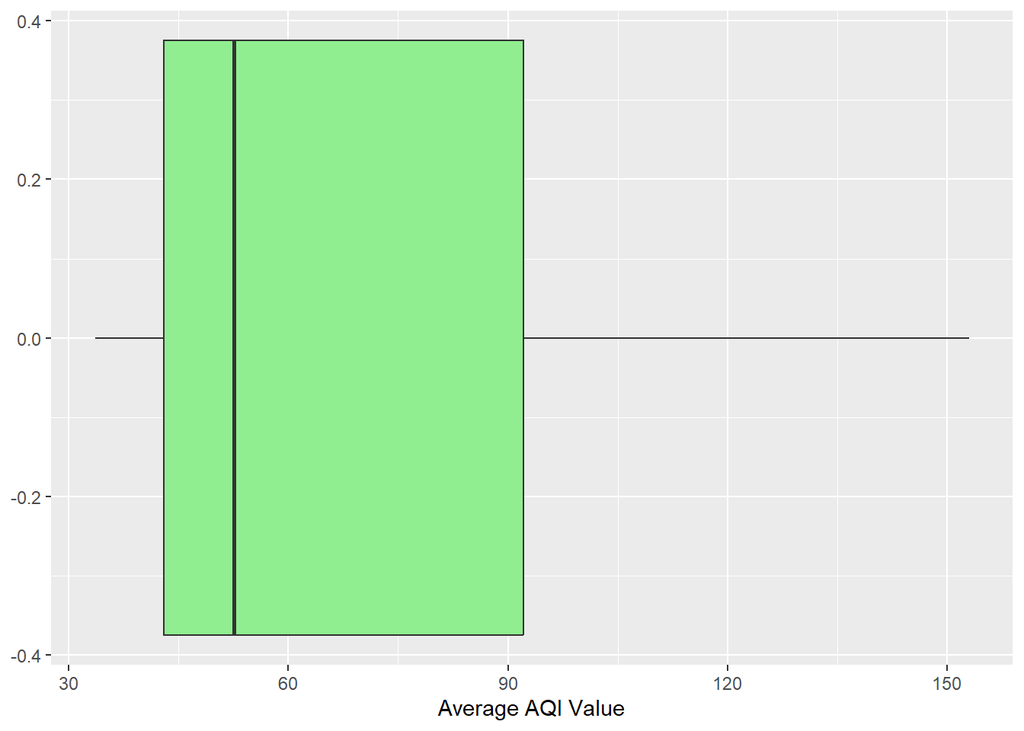

```r
ggplot(avg1t, aes(average_aqi)) +
  geom_boxplot(fill = "lightgreen") +
  labs(x="Average AQI Value")
```

Get summary stats. Because the distribution is skewed right, find median and IQR.

```r
summary(avg1t$average_aqi)
```

```
##    Min. 1st Qu.  Median    Mean 3rd Qu.    Max.
##   33.60   43.02   52.53   73.17   92.16  152.96
```

Do the same for countries with a GDP under $1 trillion.

Filter for Countries with a GDP under $1 trillion.

```r
gdput <- gdp %>%
  filter(GDP < 1000)

gdput
```

```
## # A tibble: 161 × 6
##    Country                GDP Agriculture Industry Manufacturing Services
##    <chr>                <dbl>       <dbl>    <dbl>         <dbl>    <dbl>
##  1 Switzerland           885.         0.6     24.9          18.1     71.9
##  2 Poland                811.         2.9     28.7          16.2     58.8
##  3 Argentina             641.         6.1     25.1          16.3     52.8
##  4 Belgium               632.         0.8     18.4          11.9     70.7
##  5 Sweden                593.         1.6     22.8          13.1     65.3
##  6 Ireland               546.         0.9     37.6          34.2     56.6
##  7 Austria               516          1.3     26.3          15.7     62.3
##  8 Thailand              515.         8.6     32.9          24.9     58.5
##  9 Israel                510.         1.3     17.2          10.2     72.4
## 10 United Arab Emirates  504.         0.8     51.5           9.7     47.7
## # ℹ 151 more rows
```

Join the two dataframes on Country and get rid of NA values.

```r
avgut <- gdput %>%
  left_join(averageAqi, by = "Country") %>%
  filter(!is.na(average_aqi))

avgut
```

```
## # A tibble: 119 × 7
##    Country           GDP Agriculture Industry Manufacturing Services average_aqi
##    <chr>           <dbl>       <dbl>    <dbl>         <dbl>    <dbl>       <dbl>
##  1 Switzerland      885.         0.6     24.9          18.1     71.9        55.2
##  2 Poland           811.         2.9     28.7          16.2     58.8        52.5
##  3 Argentina        641.         6.1     25.1          16.3     52.8        28.2
##  4 Belgium          632.         0.8     18.4          11.9     70.7        44.6
##  5 Sweden           593.         1.6     22.8          13.1     65.3        36.2
##  6 Ireland          546.         0.9     37.6          34.2     56.6        40.2
##  7 Austria          516          1.3     26.3          15.7     62.3        53.7
##  8 Thailand         515.         8.6     32.9          24.9     58.5        53.6
##  9 Israel           510.         1.3     17.2          10.2     72.4        87.4
## 10 United Arab Em…  504.         0.8     51.5           9.7     47.7       164.
## # ℹ 109 more rows
```

Make a bopxplot.

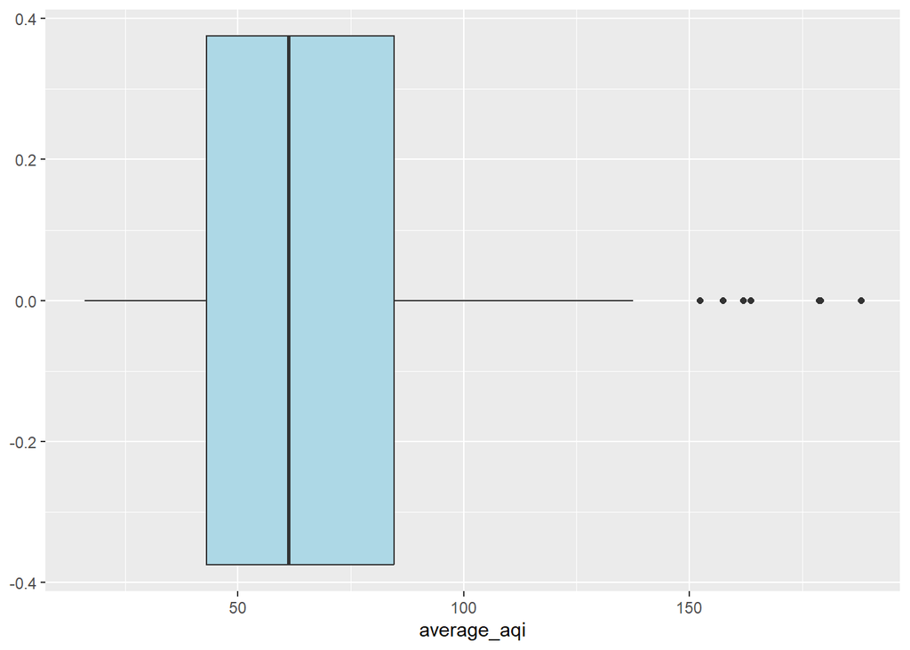

```r
ggplot(avgut, aes(average_aqi)) +
  geom_boxplot(fill = "lightblue")
```

Get summary stats. Because the distribution is skewed right, find median and IQR.

```r
summary(avgut$average_aqi)
```

```
##    Min. 1st Qu.  Median    Mean 3rd Qu.    Max.
##   16.00   43.05   61.20   67.80   84.62  188.00
```

#### Description:

Because the distributions are both skewed right, we used the median and IQR to describe its center and spread.

**Center:**

- *For countries with a GDP over $1 trillion:*
  - Median = 52.53
- *For countries with a GDP under $1 trillion:*
  - Median = 61.20

**Shape:** (can’t see as much of the shape as you would be able to with a density plot)

- *For countries with a GDP over $1 trillion:*
  - Skewed right
- *For countries with a GDP under $1 trillion:*
  - Skewed right

**Spread:**

- *For countries with a GDP over $1 trillion:*
  - Min = 33.60
  - Q1 = 43.02
  - Mean = 73.17
  - Q3 = 92.16
  - Max = 152.96
  - Larger IQR range (49.14)
- *For countries with a GDP under $1 trillion:*
  - Min = 16.00
  - Q1 = 43.05
  - Mean = 67.80
  - Q3 = 84.62
  - Max = 188.00
  - Smaller IQR range (41.57)

**Outliers:**

- *For countries with a GDP over $1 trillion:*
  - no
- *For countries with a GDP under $1 trillion:*
  - yes, multiple

Disclaimer: there are many more countries with a GDP under $1 trillion than over $1 trillion.

Both distributions are skewed right. The distribution for under $1 trillion has a greater median than the distribution for over $1 trillion, but the over distribution has a greater IQR than the under distribution. The under distribution also has a greater max and a smaller min than the over distribution and multiple outliers while the over distribution has none. I decided to make comparative boxplots out of the two distributions, but first I had to reorganize the data.

```r
gdp <- gdp %>%
  mutate(GDP_cat = ifelse(GDP > 1000, "Over", "Under"))

gdp
```

```
## # A tibble: 179 × 7
##    Country               GDP Agriculture Industry Manufacturing Services GDP_cat
##    <chr>               <dbl>       <dbl>    <dbl>         <dbl>    <dbl> <chr>
##  1 United States      27361.         0.9     17.7          10.6     76.7 Over
##  2 China              17795.         7.1     38.3          26.2     54.6 Over
##  3 Germany             4456.         0.7     28.1          19       62.6 Over
##  4 Japan               4213.         1       26.9          19.2     71.4 Over
##  5 India               3550.        16       25            12.8     49.8 Over
##  6 United Kingdom      3340          0.7     16.9           8.5     72.8 Over
##  7 France              3031.         1.9     18.7           9.7     69.2 Over
##  8 Italy               2255.         1.9     23.1          15.7     64.9 Over
##  9 Brazil              2174.         6.2     22.3          13.3     58.9 Over
## 10 Russian Federation  2021.         3.3     30.6          12.4     56.9 Over
## # ℹ 169 more rows
```

More reorganizing and joining.

```r
gdp <- gdp %>%
  left_join(averageAqi, by = "Country") %>%
  filter(!if_any(everything(), is.na))

gdp
```

```
## # A tibble: 133 × 8
##    Country               GDP Agriculture Industry Manufacturing Services GDP_cat
##    <chr>               <dbl>       <dbl>    <dbl>         <dbl>    <dbl> <chr>
##  1 China              17795.         7.1     38.3          26.2     54.6 Over
##  2 Germany             4456.         0.7     28.1          19       62.6 Over
##  3 Japan               4213.         1       26.9          19.2     71.4 Over
##  4 India               3550.        16       25            12.8     49.8 Over
##  5 France              3031.         1.9     18.7           9.7     69.2 Over
##  6 Italy               2255.         1.9     23.1          15.7     64.9 Over
##  7 Brazil              2174.         6.2     22.3          13.3     58.9 Over
##  8 Russian Federation  2021.         3.3     30.6          12.4     56.9 Over
##  9 Mexico              1789.         4       31.8          20.2     58.3 Over
## 10 Australia           1724.         2.4     27.4           5.4     64.2 Over
## # ℹ 123 more rows
## # ℹ 1 more variable: average_aqi <dbl>
```

Plot.

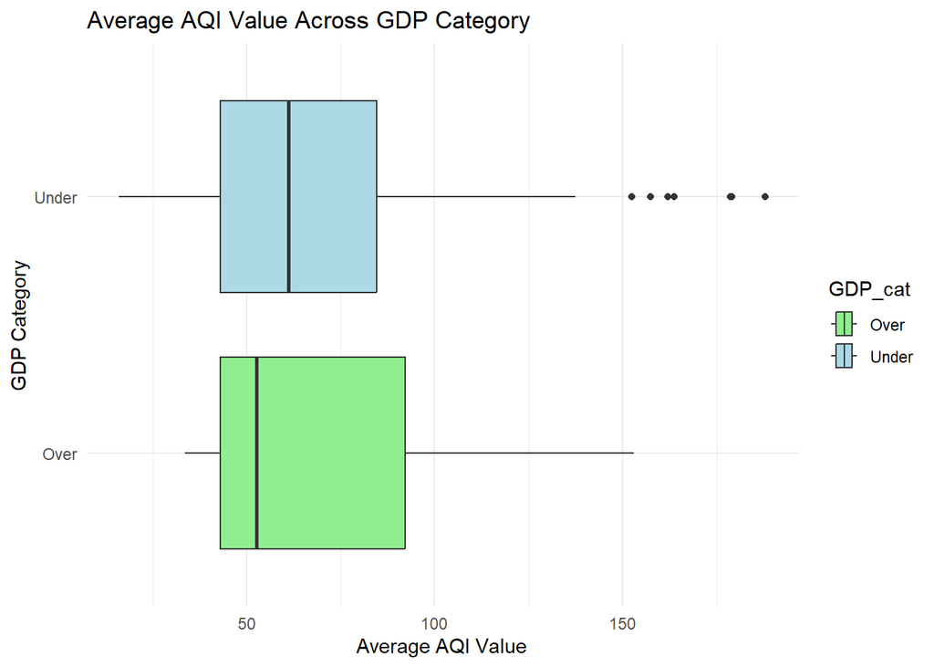

```r
ggplot(gdp, aes(x = average_aqi, y = GDP_cat, fill = GDP_cat)) +
  geom_boxplot() +
  labs(title = "Average AQI Value Across GDP Category",
       x = "Average AQI Value", y = "GDP Category") +
  scale_fill_manual(values = c("Over" = "lightgreen", "Under" = "lightblue")) +  # Custom colors for categories
  theme_minimal()
```

#### Description:

To make these horizontal side by side boxplots, we created a new categorical variable called GDP_cat. It has two levels, under and over. Under means that the country’s GDP is under $1 trillion, and over means that the country’s GDP is over $1 trillion. We also used a new numeric variable (created above) called Average AQI Value, which holds the average AQI value per country.

### Q2: How do the countries with the top 5 GDPs compare in terms of air quality?

Join data by country.

```r
combined_data <- left_join(gdp, air, by = "Country")
```

Make a new dataframe of the 5 countries with the greatest GDP.

```r
top5 <- combined_data %>%
  arrange(desc(GDP)) %>%
  filter(Country == c("China", "Germany", "Japan", "India", "France"))
top5
```

```
## # A tibble: 1,226 × 19
##    Country    GDP Agriculture Industry Manufacturing Services GDP_cat
##    <chr>    <dbl>       <dbl>    <dbl>         <dbl>    <dbl> <chr>
##  1 China   17795.         7.1     38.3          26.2     54.6 Over
##  2 China   17795.         7.1     38.3          26.2     54.6 Over
##  3 China   17795.         7.1     38.3          26.2     54.6 Over
##  4 China   17795.         7.1     38.3          26.2     54.6 Over
##  5 China   17795.         7.1     38.3          26.2     54.6 Over
##  6 China   17795.         7.1     38.3          26.2     54.6 Over
##  7 China   17795.         7.1     38.3          26.2     54.6 Over
##  8 China   17795.         7.1     38.3          26.2     54.6 Over
##  9 China   17795.         7.1     38.3          26.2     54.6 Over
## 10 China   17795.         7.1     38.3          26.2     54.6 Over
## # ℹ 1,216 more rows
## # ℹ 12 more variables: average_aqi <dbl>, City <chr>, AQI.Value <int>,
## #   AQI.Category <chr>, CO.AQI.Value <int>, CO.AQI.Category <chr>,
## #   Ozone.AQI.Value <int>, Ozone.AQI.Category <chr>, NO2.AQI.Value <int>,
## #   NO2.AQI.Category <chr>, PM2.5.AQI.Value <int>, PM2.5.AQI.Category <chr>
```

Make a comparative boxplot.

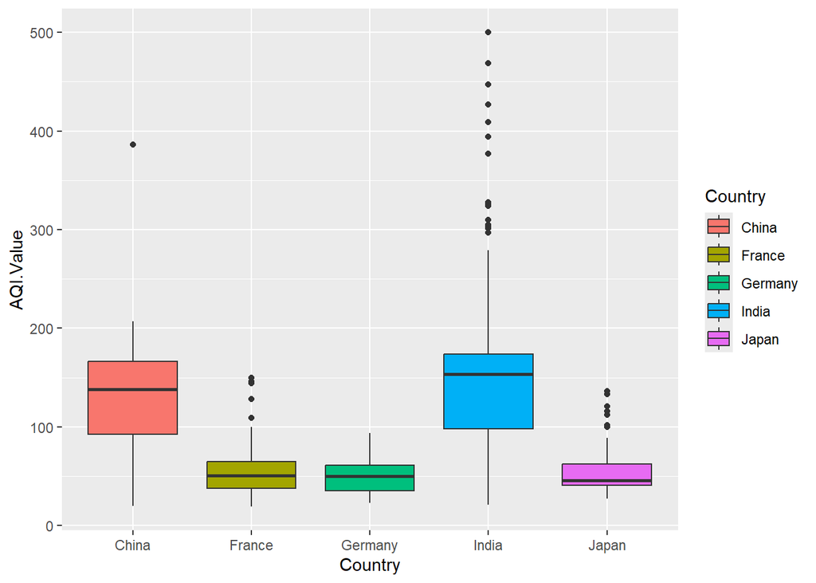

```r
ggplot(top5, aes(Country, AQI.Value, fill = Country)) +
  geom_boxplot()
```

Make a density plot.

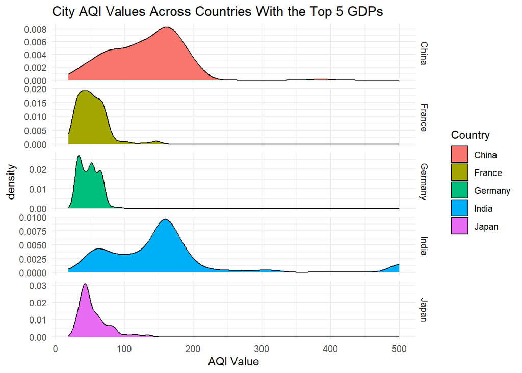

```r
ggplot(top5, aes(AQI.Value, fill = Country)) +
  geom_density() +
  facet_grid(Country~., scales = "free_y") +
  ggtitle("City AQI Values Across Countries With the Top 5 GDPs") +
  xlab("AQI Value") +
  theme_minimal()
```

Create new datasets per country for summary stat calculations.

```r
china <- top5 %>%
  filter(Country == "China")

france <- top5 %>%
  filter(Country == "France")

germany <- top5 %>%
  filter(Country == "Germany")

india <- top5 %>%
  filter(Country == "India")

japan <- top5 %>%
  filter(Country == "Japan")
```

Calculate summary stats for each country individually.

```r
summary(china$AQI.Value)
```

```
##    Min. 1st Qu.  Median    Mean 3rd Qu.    Max.
##    20.0    92.5   138.0   131.3   166.5   386.0
```

```r
summary(france$AQI.Value)
```

```
##    Min. 1st Qu.  Median    Mean 3rd Qu.    Max.
##   19.00   37.75   50.50   53.28   65.00  150.00
```

```r
summary(germany$AQI.Value)
```

```
##    Min. 1st Qu.  Median    Mean 3rd Qu.    Max.
##   23.00   35.00   50.00   48.92   61.00   94.00
```

```r
summary(india$AQI.Value)
```

```
##    Min. 1st Qu.  Median    Mean 3rd Qu.    Max.
##   21.00   98.25  153.50  159.53  174.00  500.00
```

```r
summary(japan$AQI.Value)
```

```
##    Min. 1st Qu.  Median    Mean 3rd Qu.    Max.
##   27.00   41.00   46.00   54.31   62.25  136.00
```

#### Description:

- China:
  - appears unimodal
  - appears skewed left
  - outlier
  - median = 138
  - IQR = 74
- France:
  - appears unimodal
  - appears skewed right
  - outliers
  - median = 50.50
  - IQR = 27.25
- Germany:
  - appears bimodal
  - appears skewed right
  - no outliers
  - median = 50
  - IQR = 26
- India:
  - appears bimodal
  - appears skewed right
  - outliers
  - largest IQR
  - median = 153.50
  - IQR = 75.75
- Japan:
  - appears unimodal
  - appears skewed right
  - outliers
  - smallest IQR
  - median = 46
  - IQR = 21.25

### Q3: How does GDP percentage vary across sectors?

Remove rows with missing values in sectors of interest.

```r
gdp1 <- gdp %>%
  drop_na(Agriculture, Industry, Manufacturing, Services)
```

Convert data to long format for ggplot.

```r
gdp_long <- gdp1 %>%
  pivot_longer(cols = c(Agriculture, Industry, Manufacturing, Services),
  names_to = "Sector",
  values_to = "Percentage")
```

Make comparative boxplots for GDP percentage by sector.

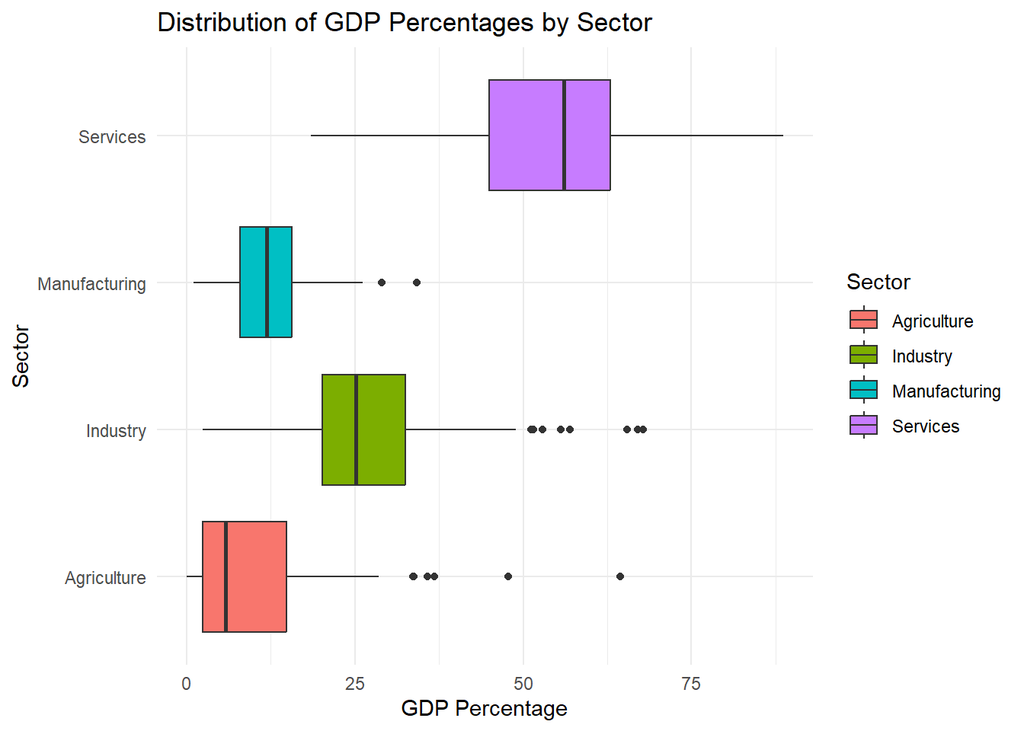

```r
ggplot(gdp_long, aes(x = Sector, y = Percentage, fill = Sector)) +
  geom_boxplot() +
  labs(title = "Distribution of GDP Percentages by Sector",
  x = "Sector",
  y = "GDP Percentage") +
  theme_minimal() +
  coord_flip()
```

Calculate summary stats for each sector individually.

```r
summary(gdp1$Agriculture)
```

```
##    Min. 1st Qu.  Median    Mean 3rd Qu.    Max.
##   0.000   2.400   5.800   9.844  14.900  64.400
```

```r
summary(gdp1$Industry)
```

```
##    Min. 1st Qu.  Median    Mean 3rd Qu.    Max.
##    2.40   20.20   25.10   27.68   32.50   67.80
```

```r
summary(gdp1$Manufacturing)
```

```
##    Min. 1st Qu.  Median    Mean 3rd Qu.    Max.
##    1.10    8.00   11.90   12.33   15.60   34.20
```

```r
summary(gdp1$Services)
```

```
##    Min. 1st Qu.  Median    Mean 3rd Qu.    Max.
##   18.50   45.00   56.00   54.79   63.00   88.60
```

##### Description:

The boxplots represent the distributions of GDP allocation across Sectors. Services appears to have the greatest percentage of GDP allocation among countries, with Industry coming in second.

# Milestone #6

### Setting Up Again

(R Studio is being finicky so I have to set up again in order to avoid an error when knitting)

Load in tidyverse.

```r
library(tidyverse)
library(ggplot2)
```

Import the datasets and rename them.

```r
library(readxl)
gdp <- read_excel("C:/Users/glwei/OneDrive/Documents/Data Sci, Intro to R/gdp_percentages_2023.xlsx")
air <- read.csv("C:/Users/glwei/OneDrive/Documents/Data Sci, Intro to R/global air pollution dataset.csv")
```

### Q1: Is there a correlation between overall GDP and a country’s average AQI value? (2 numeric variables)

Our explanatory variable is GDP and our response variable is average AQI value.

To begin, let’s filter.

```r
gdp <- gdp %>%
  filter(!Country %in% c("World", "East Asia & Pacific", "Europe & Central Asia", "Latin America & Caribbean", "Middle East & North Africa", "North America", "South Asia", "Sub-Saharan Africa")) %>%
  arrange(desc(GDP))

gdp
```

```
## # A tibble: 214 × 6
##    Country           GDP Agriculture Industry Manufacturing Services
##    <chr>           <dbl>       <dbl>    <dbl>         <dbl>    <dbl>
##  1 United States  27361.         0.9     17.7          10.6     76.7
##  2 China          17795.         7.1     38.3          26.2     54.6
##  3 Germany         4456.         0.7     28.1          19       62.6
##  4 Japan           4213.         1       26.9          19.2     71.4
##  5 India           3550.        16       25            12.8     49.8
##  6 United Kingdom  3340          0.7     16.9           8.5     72.8
##  7 France          3031.         1.9     18.7           9.7     69.2
##  8 Italy           2255.         1.9     23.1          15.7     64.9
##  9 Brazil          2174.         6.2     22.3          13.3     58.9
## 10 Canada          2140.        NA       NA            NA       NA
## # ℹ 204 more rows
```

Create a new average AQI value column.

```r
averageAqi <- air %>%
  group_by(Country) %>%
  summarize(average_aqi = mean(AQI.Value, na.rm = TRUE))

averageAqi
```

```
## # A tibble: 176 × 2
##    Country       average_aqi
##    <chr>               <dbl>
##  1 ""                   54.0
##  2 "Afghanistan"        96.0
##  3 "Albania"            68.2
##  4 "Algeria"            88.2
##  5 "Andorra"            29.3
##  6 "Angola"             83.9
##  7 "Argentina"          28.2
##  8 "Armenia"            53.6
##  9 "Aruba"             163
## 10 "Australia"          33.6
## # ℹ 166 more rows
```

Join the two dataframes on Country and get rid of NA values.

```r
airgdp <- gdp %>%
  left_join(averageAqi, by = "Country") %>%
  filter(!is.na(average_aqi))

airgdp
```

```
## # A tibble: 152 × 7
##    Country           GDP Agriculture Industry Manufacturing Services average_aqi
##    <chr>           <dbl>       <dbl>    <dbl>         <dbl>    <dbl>       <dbl>
##  1 China          17795.         7.1     38.3          26.2     54.6       127.
##  2 Germany         4456.         0.7     28.1          19       62.6        48.2
##  3 Japan           4213.         1       26.9          19.2     71.4        51.7
##  4 India           3550.        16       25            12.8     49.8       153.
##  5 France          3031.         1.9     18.7           9.7     69.2        53.3
##  6 Italy           2255.         1.9     23.1          15.7     64.9        62.0
##  7 Brazil          2174.         6.2     22.3          13.3     58.9        44.6
##  8 Canada          2140.        NA       NA            NA       NA          43.3
##  9 Russian Feder…  2021.         3.3     30.6          12.4     56.9        42.5
## 10 Mexico          1789.         4       31.8          20.2     58.3        89.5
## # ℹ 142 more rows
```

Filter for countries with a GDP over $1 trillion.

```r
gdp1t <- airgdp %>%
  filter(GDP > 1000) %>%
  arrange(desc(GDP))

gdp1t
```

```
## # A tibble: 15 × 7
##    Country           GDP Agriculture Industry Manufacturing Services average_aqi
##    <chr>           <dbl>       <dbl>    <dbl>         <dbl>    <dbl>       <dbl>
##  1 China          17795.         7.1     38.3          26.2     54.6       127.
##  2 Germany         4456.         0.7     28.1          19       62.6        48.2
##  3 Japan           4213.         1       26.9          19.2     71.4        51.7
##  4 India           3550.        16       25            12.8     49.8       153.
##  5 France          3031.         1.9     18.7           9.7     69.2        53.3
##  6 Italy           2255.         1.9     23.1          15.7     64.9        62.0
##  7 Brazil          2174.         6.2     22.3          13.3     58.9        44.6
##  8 Canada          2140.        NA       NA            NA       NA          43.3
##  9 Russian Feder…  2021.         3.3     30.6          12.4     56.9        42.5
## 10 Mexico          1789.         4       31.8          20.2     58.3        89.5
## 11 Australia       1724.         2.4     27.4           5.4     64.2        33.6
## 12 Spain           1581.         2.3     20.2          11.5     68.5        38.5
## 13 Indonesia       1371.        12.5     40.2          18.7     42.9        93.0
## 14 Netherlands     1118.         1.5     19.4          11.6     69.3        38.1
## 15 Saudi Arabia    1068.         2.7     47            14.8     44.9       149.
```

Create a scatterplot of GDP over $1 Trillion (x) vs. Average AQI Value (y).

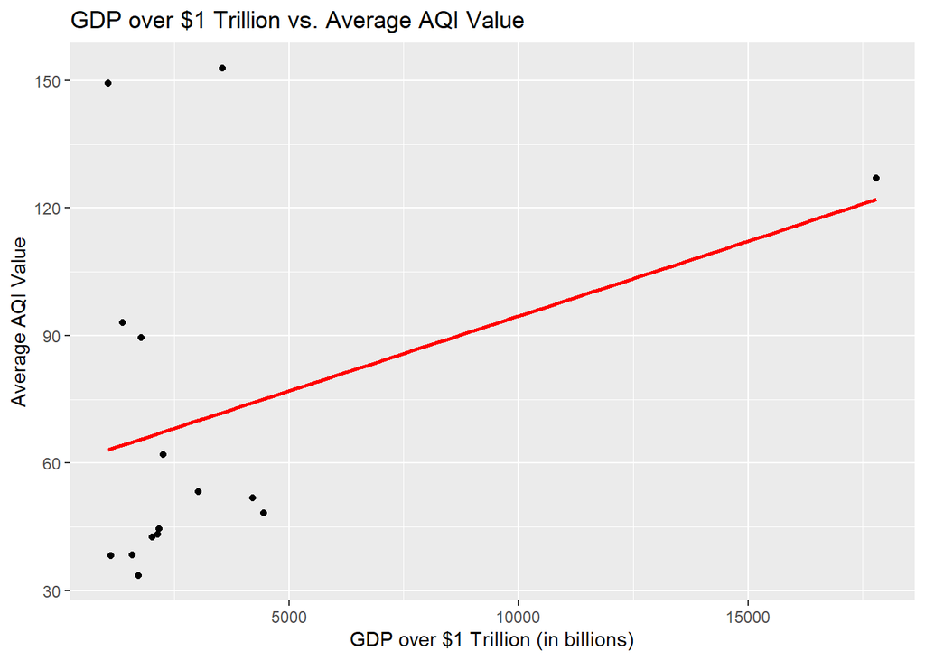

```r
ggplot(gdp1t, aes(GDP, average_aqi)) +
  geom_point() +
  geom_smooth(method = "lm", se = FALSE, color = "red") +
  ggtitle("GDP over $1 Trillion vs. Average AQI Value") +
  xlab("GDP over $1 Trillion (in billions)") +
  ylab("Average AQI Value")
```

Correlation coefficient.

```r
cor(gdp1t$GDP, gdp1t$average_aqi)
```

```
## [1] 0.3520535
```

Fit a linear model.

```r
gdp1t_model <- lm(average_aqi~GDP, gdp1t)
summary(gdp1t_model)
```

```
##
## Call:
## lm(formula = average_aqi ~ GDP, data = gdp1t)
##
## Residuals:
##    Min     1Q Median     3Q    Max
## -31.84 -24.57 -22.45  14.39  86.16
##
## Coefficients:
##              Estimate Std. Error t value Pr(>|t|)
## (Intercept) 59.369121  13.534584   4.386 0.000736 ***
## GDP          0.003522   0.002597   1.356 0.198134
## ---
## Signif. codes:  0 '***' 0.001 '**' 0.01 '*' 0.05 '.' 0.1 ' ' 1
##
## Residual standard error: 40.14 on 13 degrees of freedom
## Multiple R-squared:  0.1239, Adjusted R-squared:  0.05655
## F-statistic: 1.839 on 1 and 13 DF,  p-value: 0.1981
```

#### Description:

The r value 0.352 and the graph indicate a weak, positive, linear correlation with one major outlier on the x-axis. The slope of the regression line is 0.003522 and the y-intercept is 59.369121. This means that for every one-unit increase in GDP for countries with GDP over $1 trillion, the predicted average AQI value increases by 0.003522 units.

Filter for Countries with a GDP under $1 trillion.

```r
gdput <- airgdp %>%
  filter(GDP < 1000)

gdput
```

```
## # A tibble: 134 × 7
##    Country           GDP Agriculture Industry Manufacturing Services average_aqi
##    <chr>           <dbl>       <dbl>    <dbl>         <dbl>    <dbl>       <dbl>
##  1 Switzerland      885.         0.6     24.9          18.1     71.9        55.2
##  2 Poland           811.         2.9     28.7          16.2     58.8        52.5
##  3 Argentina        641.         6.1     25.1          16.3     52.8        28.2
##  4 Belgium          632.         0.8     18.4          11.9     70.7        44.6
##  5 Sweden           593.         1.6     22.8          13.1     65.3        36.2
##  6 Ireland          546.         0.9     37.6          34.2     56.6        40.2
##  7 Austria          516          1.3     26.3          15.7     62.3        53.7
##  8 Thailand         515.         8.6     32.9          24.9     58.5        53.6
##  9 Israel           510.         1.3     17.2          10.2     72.4        87.4
## 10 United Arab Em…  504.         0.8     51.5           9.7     47.7       164.
## # ℹ 124 more rows
```

Create a scatterplot of GDP under $1 Trillion (x) vs. Average AQI Value (y).

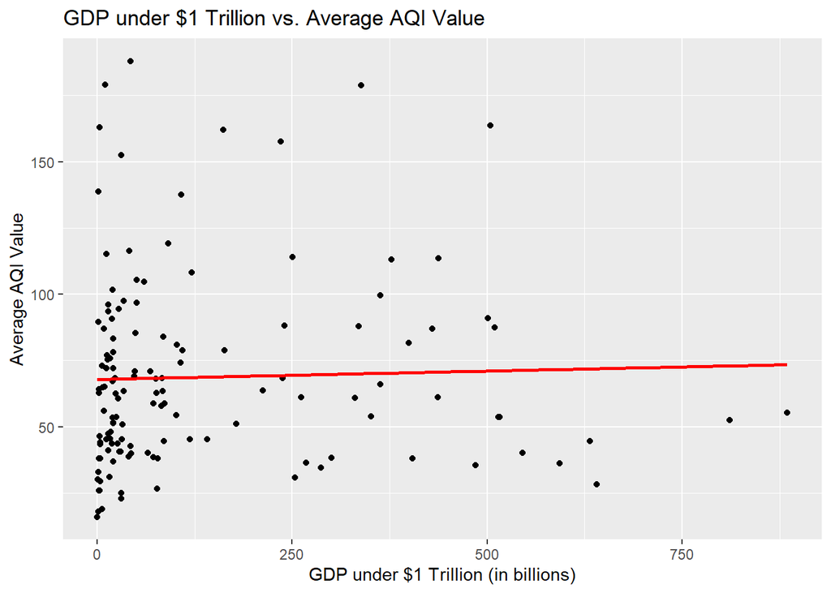

```r
ggplot(gdput, aes(GDP, average_aqi)) +
  geom_point() +
  geom_smooth(method = "lm", se = FALSE, color = "red") +
  ggtitle("GDP under $1 Trillion vs. Average AQI Value") +
  xlab("GDP under $1 Trillion (in billions)") +
  ylab("Average AQI Value")
```

Correlation coefficient.

```r
cor(gdput$GDP, gdput$average_aqi)
```

```
## [1] 0.03255637
```

Fit a linear model.

```r
gdput_model <- lm(average_aqi~GDP, gdput)
summary(gdput_model)
```

```
##
## Call:
## lm(formula = average_aqi ~ GDP, data = gdput)
##
## Residuals:
##    Min     1Q Median     3Q    Max
## -51.91 -25.21  -6.58  16.41 119.82
##
## Coefficients:
##              Estimate Std. Error t value Pr(>|t|)
## (Intercept) 67.911430   3.867911  17.558   <2e-16 ***
## GDP          0.006256   0.016717   0.374    0.709
## ---
## Signif. codes:  0 '***' 0.001 '**' 0.01 '*' 0.05 '.' 0.1 ' ' 1
##
## Residual standard error: 36.13 on 132 degrees of freedom
## Multiple R-squared:  0.00106,    Adjusted R-squared:  -0.006508
## F-statistic: 0.1401 on 1 and 132 DF,  p-value: 0.7088
```

#### Description:

The r value 0.0326 and the graph indicate a very weak, positive, linear correlation with multiple possible outliers on the x and y-axis. The slope of the regression line is 0.006256 and the y-intercept is 67.911430. This means that for every one-unit increase in GDP for countries with GDP under $1 trillion, the predicted average AQI value increases by 0.006256 units.

### Q2: How do average AQI values differ between countries that allocate the maximum percentage of their GDP to industry versus those that allocate the maximum to another sector?

Use mutate to create new variables (max_percentage and max_sector). Max_sector is a new categorical variable listing the sector with the highest percentage of GDP allocation (max_percentage) in its respective country.

```r
highest_section <- airgdp %>%
  mutate(
    max_percentage = pmax(Industry, Services, Manufacturing, Agriculture, na.rm = TRUE),
    max_sector = case_when(
      max_percentage == Industry ~ "Industry",
      max_percentage == Services ~ "Services",
      max_percentage == Manufacturing ~ "Manufacturing",
      max_percentage == Agriculture ~ "Agriculture",
      TRUE ~ NA_character_
    )
  ) %>%
  select(-Industry, -Services, -Manufacturing, -Agriculture, -GDP, -average_aqi)  # drop unwanted columns

highest_section
```

```
## # A tibble: 152 × 3
##    Country            max_percentage max_sector
##    <chr>                       <dbl> <chr>
##  1 China                        54.6 Services
##  2 Germany                      62.6 Services
##  3 Japan                        71.4 Services
##  4 India                        49.8 Services
##  5 France                       69.2 Services
##  6 Italy                        64.9 Services
##  7 Brazil                       58.9 Services
##  8 Canada                       NA   <NA>
##  9 Russian Federation           56.9 Services
## 10 Mexico                       58.3 Services
## # ℹ 142 more rows
```

Join the two dataframes on Country and get rid of NA values.

```r
allmax <- airgdp %>%
  left_join(highest_section, by = "Country") %>%
  filter(!is.na(max_sector)) %>%
  na.omit()

allmax
```

```
## # A tibble: 133 × 9
##    Country           GDP Agriculture Industry Manufacturing Services average_aqi
##    <chr>           <dbl>       <dbl>    <dbl>         <dbl>    <dbl>       <dbl>
##  1 China          17795.         7.1     38.3          26.2     54.6       127.
##  2 Germany         4456.         0.7     28.1          19       62.6        48.2
##  3 Japan           4213.         1       26.9          19.2     71.4        51.7
##  4 India           3550.        16       25            12.8     49.8       153.
##  5 France          3031.         1.9     18.7           9.7     69.2        53.3
##  6 Italy           2255.         1.9     23.1          15.7     64.9        62.0
##  7 Brazil          2174.         6.2     22.3          13.3     58.9        44.6
##  8 Russian Feder…  2021.         3.3     30.6          12.4     56.9        42.5
##  9 Mexico          1789.         4       31.8          20.2     58.3        89.5
## 10 Australia       1724.         2.4     27.4           5.4     64.2        33.6
## # ℹ 123 more rows
## # ℹ 2 more variables: max_percentage <dbl>, max_sector <chr>
```

Filter for when max sector == industry.

```r
indust <- allmax %>%
  filter(max_sector == "Industry")

indust
```

```
## # A tibble: 17 × 9
##    Country           GDP Agriculture Industry Manufacturing Services average_aqi
##    <chr>           <dbl>       <dbl>    <dbl>         <dbl>    <dbl>       <dbl>
##  1 Saudi Arabia   1068.          2.7     47            14.8     44.9       149.
##  2 United Arab E…  504.          0.8     51.5           9.7     47.7       164.
##  3 Iraq            251.          2.8     55.6           3.6     42.3       114.
##  4 Qatar           236.          0.3     65.4           9.3     38.5       158.
##  5 Kuwait          162.          0.4     67             6.9     43.6       162
##  6 Oman            108.          1.8     57            10.5     44.5       138.
##  7 Angola           84.7        14.9     45.3           8       39.7        83.9
##  8 Azerbaijan       72.4         5.5     46.6           5.8     39.1        58.8
##  9 Cambodia         31.8        21.5     38.5          18.3     33.4        45.2
## 10 Papua New Gui…   30.9        16.9     40.3           1.6     39          24.9
## 11 Trinidad and …   28.1         1.1     48.9          22.2     47.8        94.5
## 12 Zimbabwe         26.5        27       46.9          13.8     18.5        43.7
## 13 Gabon            20.5         5.8     52.9          21.6     36.4        78.1
## 14 Guyana           16.8        10       67.8           1.9     19.3        45.5
## 15 Equatorial Gu…   12.1         2.9     51.2           5.9     44.9        45.2
## 16 Tajikistan       12.1        22.9     34.7          15.1     34.1       115.
## 17 Suriname          3.8         8.1     44.8          29       44.7        43.3
## # ℹ 2 more variables: max_percentage <dbl>, max_sector <chr>
```

Plot.

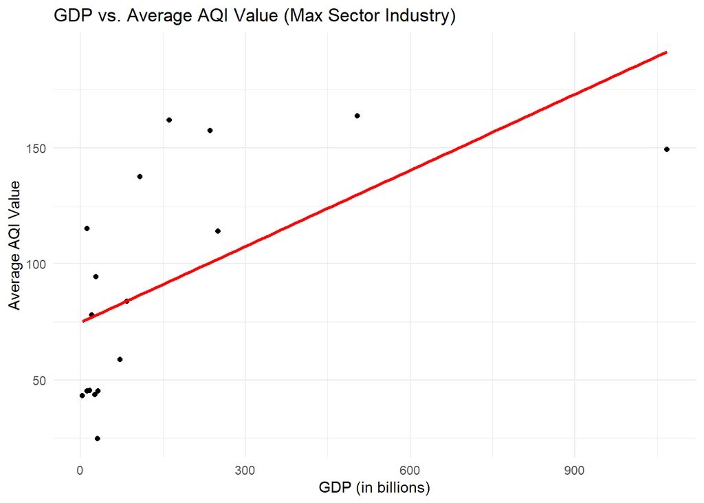

```r
ggplot(indust, aes(GDP, average_aqi)) +
  geom_point() +
  geom_smooth(method = "lm", se = FALSE, color = "red") +
  ggtitle("GDP vs. Average AQI Value (Max Sector Industry)") +
  xlab("GDP (in billions)") +
  ylab("Average AQI Value") +
  theme_minimal()
```

Correlation coefficient.

```r
cor(indust$GDP, indust$average_aqi)
```

```
## [1] 0.601604
```

Fit a linear model.

```r
indust_model <- lm(average_aqi~GDP, indust)
summary(indust_model)
```

```
##
## Call:
## lm(formula = average_aqi ~ GDP, data = indust)
##
## Residuals:
##     Min      1Q  Median      3Q     Max
## -53.284 -31.859  -0.097  33.852  69.561
##
## Coefficients:
##             Estimate Std. Error t value Pr(>|t|)
## (Intercept) 74.77757   11.36256   6.581 8.72e-06 ***
## GDP          0.10916    0.03742   2.917   0.0106 *
## ---
## Signif. codes:  0 '***' 0.001 '**' 0.01 '*' 0.05 '.' 0.1 ' ' 1
##
## Residual standard error: 40.1 on 15 degrees of freedom
## Multiple R-squared:  0.3619, Adjusted R-squared:  0.3194
## F-statistic: 8.508 on 1 and 15 DF,  p-value: 0.01062
```

#### Description:

The r value 0.6016 and the graph indicate a moderately strong, positive, linear correlation with a possible outlier on the x-axis. The slope of the regression line is 0.10916 and the y-intercept is 74.77757. This means that for every one-unit increase in GDP for countries with a max sector of industry, the predicted average AQI value increases by 0.10916 units.

Filter for when max sector == services.

```r
serv <- allmax %>%
  filter(max_sector == "Services") %>%
  na.omit()

serv
```

```
## # A tibble: 113 × 9
##    Country           GDP Agriculture Industry Manufacturing Services average_aqi
##    <chr>           <dbl>       <dbl>    <dbl>         <dbl>    <dbl>       <dbl>
##  1 China          17795.         7.1     38.3          26.2     54.6       127.
##  2 Germany         4456.         0.7     28.1          19       62.6        48.2
##  3 Japan           4213.         1       26.9          19.2     71.4        51.7
##  4 India           3550.        16       25            12.8     49.8       153.
##  5 France          3031.         1.9     18.7           9.7     69.2        53.3
##  6 Italy           2255.         1.9     23.1          15.7     64.9        62.0
##  7 Brazil          2174.         6.2     22.3          13.3     58.9        44.6
##  8 Russian Feder…  2021.         3.3     30.6          12.4     56.9        42.5
##  9 Mexico          1789.         4       31.8          20.2     58.3        89.5
## 10 Australia       1724.         2.4     27.4           5.4     64.2        33.6
## # ℹ 103 more rows
## # ℹ 2 more variables: max_percentage <dbl>, max_sector <chr>
```

Plot.

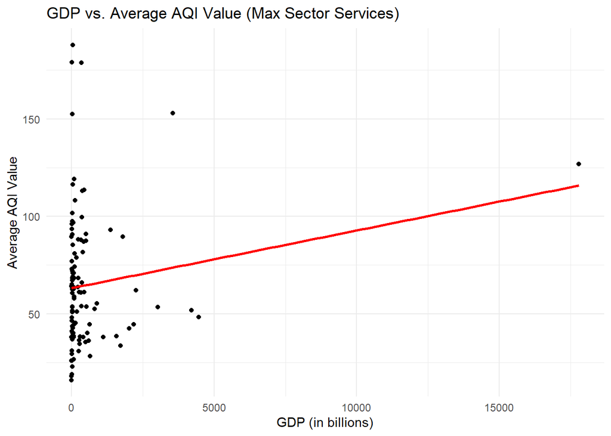

```r
ggplot(serv, aes(GDP, average_aqi)) +
  geom_point() +
  geom_smooth(method = "lm", se = FALSE, color = "red") +
  ggtitle("GDP vs. Average AQI Value (Max Sector Services)") +
  xlab("GDP (in billions)") +
  ylab("Average AQI Value") +
  theme_minimal()
```

Correlation coefficient.

```r
cor(serv$GDP, serv$average_aqi)
```

```
## [1] 0.1617831
```

Fit a linear model.

```r
serv_model <- lm(average_aqi~GDP, serv)
summary(serv_model)
```

```
##
## Call:
## lm(formula = average_aqi ~ GDP, data = serv)
##
## Residuals:
##     Min      1Q  Median      3Q     Max
## -47.184 -24.471  -5.493  15.064 124.689
##
## Coefficients:
##              Estimate Std. Error t value Pr(>|t|)
## (Intercept) 63.183492   3.257510  19.396   <2e-16 ***
## GDP          0.002959   0.001713   1.727   0.0869 .
## ---
## Signif. codes:  0 '***' 0.001 '**' 0.01 '*' 0.05 '.' 0.1 ' ' 1
##
## Residual standard error: 33.09 on 111 degrees of freedom
## Multiple R-squared:  0.02617,    Adjusted R-squared:  0.0174
## F-statistic: 2.983 on 1 and 111 DF,  p-value: 0.08691
```

#### Description:

The r value 0.1618 and the graph indicate a very weak, positive, linear correlation with a possible outlier on the x-axis. The slope of the regression line is 0.002959 and the y-intercept is 63.183492. This means that for every one-unit increase in GDP for countries with a max sector of services, the predicted average AQI value increases by 0.002959 units.

Filter for when max sector == agriculture.

```r
agri <- allmax %>%
  filter(max_sector == "Agriculture")

agri
```

```
## # A tibble: 3 × 9
##   Country        GDP Agriculture Industry Manufacturing Services average_aqi
##   <chr>        <dbl>       <dbl>    <dbl>         <dbl>    <dbl>       <dbl>
## 1 Mali          20.9        36.8     19.4           6       36.1        83.2
## 2 Niger         16.8        47.8     20.2           7.2     26.9        75.7
## 3 Sierra Leone   3.8        64.4      7.8           1.6     24.7        44.2
## # ℹ 2 more variables: max_percentage <dbl>, max_sector <chr>
```

Plot.

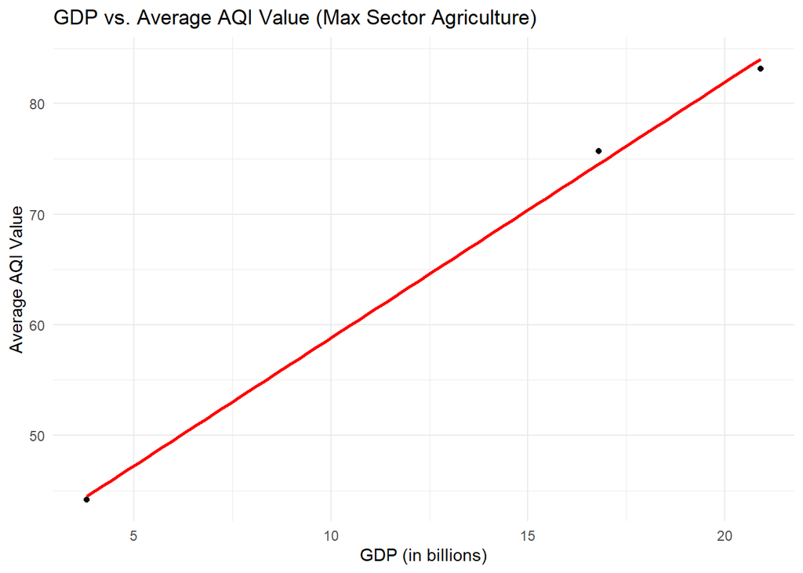

```r
ggplot(agri, aes(GDP, average_aqi)) +
  geom_point() +
  geom_smooth(method = "lm", se = FALSE, color = "red") +
  ggtitle("GDP vs. Average AQI Value (Max Sector Agriculture)") +
  xlab("GDP (in billions)") +
  ylab("Average AQI Value") +
  theme_minimal()
```

Correlation coefficient.

```r
cor(agri$GDP, agri$average_aqi)
```

```
## [1] 0.9987477
```

Fit a linear model.

```r
agri_model <- lm(average_aqi~GDP, agri)
summary(agri_model)
```

```
##
## Call:
## lm(formula = average_aqi ~ GDP, data = agri)
##
## Residuals:
##       1       2       3
## -0.8697  1.1440 -0.2743
##
## Coefficients:
##             Estimate Std. Error t value Pr(>|t|)
## (Intercept)  35.6842     1.8119   19.70   0.0323 *
## GDP           2.3132     0.1159   19.96   0.0319 *
## ---
## Signif. codes:  0 '***' 0.001 '**' 0.01 '*' 0.05 '.' 0.1 ' ' 1
##
## Residual standard error: 1.463 on 1 degrees of freedom
## Multiple R-squared:  0.9975, Adjusted R-squared:  0.995
## F-statistic: 398.5 on 1 and 1 DF,  p-value: 0.03186
```

#### Description:

The r value 0.9987 and the graph indicate a very strong, positive, linear correlation with no outliers. There are also only three points, so it’s not the best graph or model. The slope of the regression line is 2.3132 and the y-intercept is 35.6842. This means that for every one-unit increase in GDP for countries with a max sector of agriculture, the predicted average AQI value increases by 2.3132 units.

There are no rows where max sector == manufacturing, so let’s move on.

Plot everything together. It looks pretty bad (China is a massive outlier, and most max sectors are Services).

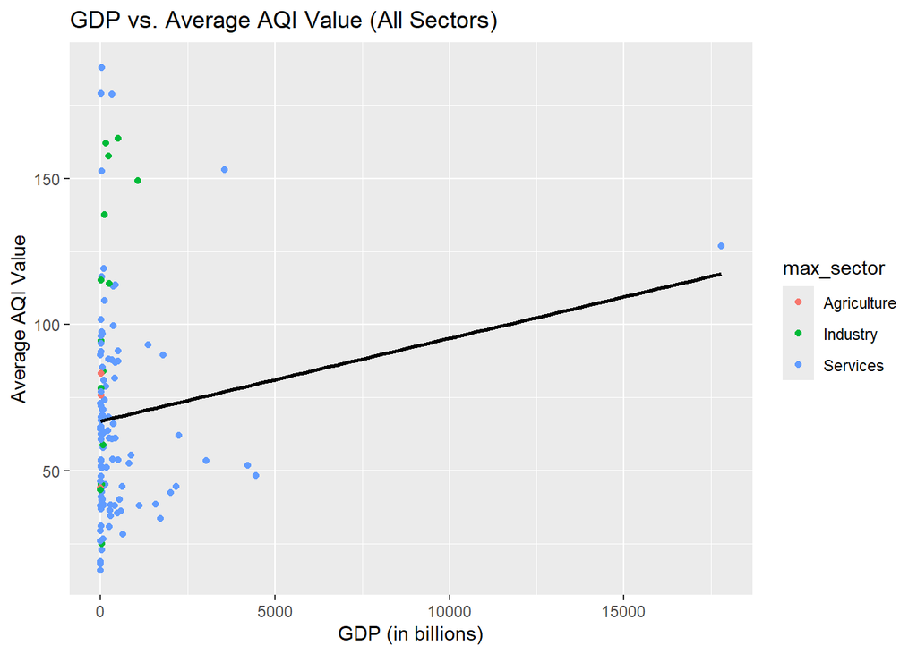

```r
ggplot(allmax, aes(GDP, average_aqi, color = max_sector)) +
  geom_point() +
  geom_smooth(method = "lm", se = FALSE, color = "black") +
  ggtitle("GDP vs. Average AQI Value (All Sectors)") +
  xlab("GDP (in billions)") +
  ylab("Average AQI Value")
```

Correlation coefficient.

```r
cor(allmax$GDP, allmax$average_aqi)
```

```
## [1] 0.1318359
```

Fit a linear model.

```r
allmax_model <- lm(average_aqi~GDP, allmax)
summary(allmax_model)
```

```
##
## Call:
## lm(formula = average_aqi ~ GDP, data = allmax)
##
## Residuals:
##     Min      1Q  Median      3Q     Max
## -50.960 -26.445  -7.002  17.509 120.919
##
## Coefficients:
##              Estimate Std. Error t value Pr(>|t|)
## (Intercept) 66.958830   3.268685  20.485   <2e-16 ***
## GDP          0.002834   0.001862   1.522     0.13
## ---
## Signif. codes:  0 '***' 0.001 '**' 0.01 '*' 0.05 '.' 0.1 ' ' 1
##
## Residual standard error: 36.16 on 131 degrees of freedom
## Multiple R-squared:  0.01738,    Adjusted R-squared:  0.00988
## F-statistic: 2.317 on 1 and 131 DF,  p-value: 0.1304
```

#### Description:

The r value 0.1318 and the graph indicate a very weak, positive, linear correlation with a possible outlier on the x-axis. The slope of the regression line is 0.002834 and the y-intercept is 66.958830. This means that for every one-unit increase in GDP, the predicted average AQI value increases by 0.002834 units.

### Creating and evaluating more linear models

Create a scatterplot of GDP vs. average AQI value with a linear fit.

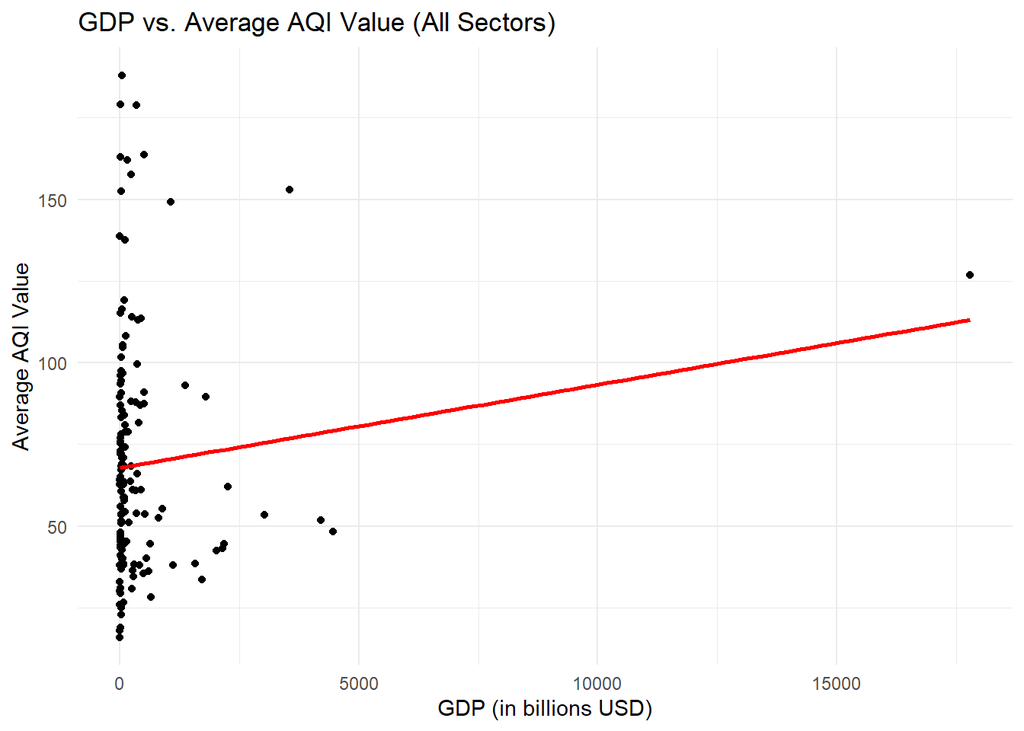

```r
# Scatter Plot with Linear Fit
ggplot(airgdp, aes(x = GDP, y = average_aqi)) +
  geom_point() +
  geom_smooth(method = "lm", color = "red", se = FALSE) +
  labs(title = "GDP vs. Average AQI Value (All Sectors)",
  x = "GDP (in billions USD)",
  y = "Average AQI Value") +
  theme_minimal()
```

R = 0.1123833

Make a linear model between the two variables.

```r
# Linear Regression Analysis
linear_model <- lm(average_aqi ~ GDP, data = airgdp)
summary(linear_model)
```

```
##
## Call:
## lm(formula = average_aqi ~ GDP, data = airgdp)
##
## Residuals:
##     Min      1Q  Median      3Q     Max
## -51.838 -27.242  -7.754  17.355 120.053
##
## Coefficients:
##              Estimate Std. Error t value Pr(>|t|)
## (Intercept) 67.837127   3.096054  21.911   <2e-16 ***
## GDP          0.002545   0.001856   1.371    0.172
## ---
## Signif. codes:  0 '***' 0.001 '**' 0.01 '*' 0.05 '.' 0.1 ' ' 1
##
## Residual standard error: 36.32 on 147 degrees of freedom
##   (3 observations deleted due to missingness)
## Multiple R-squared:  0.01263,    Adjusted R-squared:  0.005917
## F-statistic: 1.881 on 1 and 147 DF,  p-value: 0.1723
```

Create a new categorical variable for GDP grouping called GDP_Group, where GDP is sorted into either above 2000 billion (High GDP) or under 2000 billion (Low GDP).

```r
# Create a new categorical variable for GDP grouping
# Assume GDP over 2000 billion as "High GDP", and below as "Low GDP"
gdp2 <- airgdp %>%
  mutate(GDP_Group = ifelse(GDP > 2000, "High GDP", "Low GDP")) %>%
  na.omit()
```

Create a scatterplot of GDP vs. average AQI value with a linear fit and colored by GDP Group.

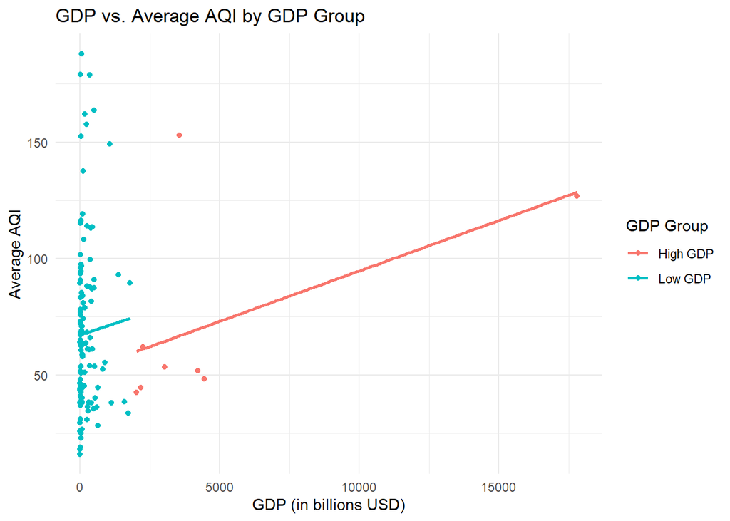

```r
# Scatter Plot with Linear Fit and Color by GDP Group
ggplot(gdp2, aes(x = GDP, y = average_aqi, color = GDP_Group)) +
  geom_point() +
  geom_smooth(method = "lm", se = FALSE) +
  labs(title = "GDP vs. Average AQI by GDP Group",
  x = "GDP (in billions USD)",
  y = "Average AQI",
  color = "GDP Group") +
  theme_minimal()
```

Fit separate models for each GDP group.

```r
# Linear Regression Analysis with Color Grouping
# Fit separate models for each GDP group
model_high <- lm(average_aqi ~ GDP, data = gdp2 %>% filter(GDP_Group == "High GDP"))

model_low <- lm(average_aqi ~ GDP, data = gdp2 %>% filter(GDP_Group == "Low GDP"))
```

Call summary stats for each model.

```r
# High GDP model
summary(model_high)
```

```
##
## Call:
## lm(formula = average_aqi ~ GDP, data = gdp2 %>% filter(GDP_Group ==
##     "High GDP"))
##
## Residuals:
##     Min      1Q  Median      3Q     Max
## -22.460 -17.722 -13.720  -0.941  86.183
##
## Coefficients:
##              Estimate Std. Error t value Pr(>|t|)
## (Intercept) 51.404082  19.319254   2.661   0.0375 *
## GDP          0.004332   0.002767   1.565   0.1685
## ---
## Signif. codes:  0 '***' 0.001 '**' 0.01 '*' 0.05 '.' 0.1 ' ' 1
##
## Residual standard error: 38.64 on 6 degrees of freedom
## Multiple R-squared:   0.29,  Adjusted R-squared:  0.1716
## F-statistic:  2.45 on 1 and 6 DF,  p-value: 0.1685
```

#### Description:

The r squared value 0.29 suggests a weak, positive, linear correlation. The slope of the regression line is 0.004332 and the y-intercept is 51.404082. This means that for every one-unit increase in GDP, the predicted average AQI value increases by 0.004332 units.

```r
# Low GDP model
summary(model_low)
```

```
##
## Call:
## lm(formula = average_aqi ~ GDP, data = gdp2 %>% filter(GDP_Group ==
##     "Low GDP"))
##
## Residuals:
##     Min      1Q  Median      3Q     Max
## -51.242 -26.297  -7.066  17.882 120.588
##
## Coefficients:
##              Estimate Std. Error t value Pr(>|t|)
## (Intercept) 67.240328   3.820209  17.601   <2e-16 ***
## GDP          0.003966   0.009530   0.416    0.678
## ---
## Signif. codes:  0 '***' 0.001 '**' 0.01 '*' 0.05 '.' 0.1 ' ' 1
##
## Residual standard error: 36.21 on 123 degrees of freedom
## Multiple R-squared:  0.001406,   Adjusted R-squared:  -0.006713
## F-statistic: 0.1732 on 1 and 123 DF,  p-value: 0.678
```

#### Description:

The r squared value 0.0014 suggests a very weak, positive, linear correlation. The slope of the regression line is 0.003966 and the y-intercept is 67.240328. This means that for every one-unit increase in GDP, the predicted average AQI value increases by 0.003966 units.